# study 1 analysis

Joseph Outa

2025-7-1

Background: This is the analysis script for the main study of study 1, that is, the replication of Study 1 of the 2025 Cogsci Paper: “Adults hold two parallel causal frameworks for reasoning about people’s minds, actions and bodies” by Joseph Outa and Shari Liu.

This study was conducted on 6/30/25 on Connect CloudResearch, N = 102 participants.

Study 1 presented two tasks in a random order in a within-subjects design: a Freesorting Task and a Causal Task. Subjects sorted 15 items in a sorting canvas, and rated causal relatedness between all 210 pairs of the 15 items (excluding self pairs).

The N was 102 adults (before exclusions), recruited online via Cloud Research Connect. Study demo: https://liulaboratory-experiments.github.io/mbc/study1.

The two research questions are: (1) How do subjects sort items? Do they sort based on three latent causes, 2 latent causes, 6 latent causes, or feature-based similarity. (2) Do subjects’ direct cause representations (from the Causal Task) reflect latent cause boundaries or do they go beyond, and if so, what is their structure?

The manuscript and project materials for the pilot study can be found at: https://github.com/liulaboratory-experiments/mind-body-action-causation

Script description: This script:-  
- proceeds from the output of the preprocessing script.  
- takes as input `data_processed_step1.csv`, and `data_model_prediction.csv` - plots Sorting and Causal Task rdms, gets correlations between empirical and models RDM, gets within subject correlations.  
- outputs `data_freesort_mins_causals.csv` for use in study 2 script for item selection.

What this script does: Per-subject normalize, followed by average, followed be renormalizing. For correlations with models: only correlates upper tris. (what about causal?). Also, this script is more uptodate than both main and combined scripts on posit and the combined script on my computer, as at 4/9/26 writing PNAS paper.

#Todo if time: change “bio” to “body”, fix header order

# 1 Setup

## 1.1 Load packages

## 1.2 Set variables

```r
# variables
desired_order <- c("see something", "hear something", "choose what to do",
                   "remember something", "think about something", "reach for something",
                   "sit down", "jump up and down", "kick something", "take a walk",
                   "get tired", "become hungry", "feel scared", "experience pain", "get sick")
domain_order <- c("mind", "action", "bio")
freesort_columns <- c("subject_id", "x", "y", "item")
freesort_columns_with_trial_order <- c("subject_id", "x", "y", "item", "trial_type", "trial_type_order")
causation_columns <- c("subject_id", "itemA", "itemB", "response")

# paths
## script inputs
base_path <- here("code", "main", "analysis", "1_measure-main-only")
snapshots_input_path <- paste0(base_path, "/snapshots_study1_preprocessing_analysis")
data_input_path <- paste0(snapshots_input_path, "/main_data_processed_step1.csv")
model_predictions_input_path <- paste0(snapshots_input_path, "/data_model_predictions.csv")
rdms_input_path <- paste0(base_path, "/figures/theoretical-rdms")

## script outputs
snapshots_output_path <- paste0(base_path, "/snapshots_study1_main_analysis")
rdms_outputs_path <- paste0(base_path, "/figures")
freesort_minus_causal_distances_output_path <- paste0(snapshots_output_path, "/freesort_minus_causals.csv")

## saved dataframes
data_processed_output_path <- paste0(snapshots_output_path, "/main_data_processed_step2.csv") #used in item-selection-main script
correlations_output_path <- paste0(snapshots_output_path, "/correlations.csv") #not used in this script
```

## 1.3 Read data

```r
d <- read_csv(data_input_path)
#how many subjects
d %>%
  slice(length(d$subject_id)) %>%
  pull(subject_id)
```

```
## [1] "subj_102"
```

## 1.4 Reshape data

Create separate data frames for Sorting Task, Causal Task and a combined data frame

```r
df_causal <- d %>%
  filter(trial_type == "causation", !attention_check, itemA != itemB) %>%
  select(all_of(causation_columns)) %>%

  #normalize causal distances and flip scale
  mutate(
    causal_distance = (1 - response / 100 - min(1 - response / 100, na.rm = TRUE)) /
                            (max(1 - response / 100, na.rm = TRUE) - min(1 - response / 100, na.rm = TRUE))
  ) %>%
  select(subject_id, itemA, itemB, causal_distance) %>%
  mutate(domain_itemA = case_when(itemA == "hear something" ~ "mind", #labels for first item of pair
                             itemA == "choose what to do" ~ "mind",
                             itemA == "remember something" ~ "mind",
                             itemA == "think about something" ~ "mind",
                             itemA == "see something" ~ "mind",
                             itemA == "reach for something" ~ "action",
                             itemA == "sit down" ~ "action",
                             itemA == "jump up and down" ~ "action",
                             itemA == "kick something" ~ "action",
                             itemA == "take a walk" ~ "action",
                             itemA == "get tired" ~ "bio",
                             itemA == "become hungry" ~ "bio",
                             itemA == "feel scared"~ "bio",
                             itemA == "experience pain"~ "bio",
                             itemA == "get sick"~ "bio"),
         domain_itemB = case_when(itemB == "hear something" ~ "mind",
                               itemB == "choose what to do" ~ "mind",
                               itemB == "remember something" ~ "mind",
                               itemB == "think about something" ~ "mind",
                               itemB == "see something" ~ "mind",
                               itemB == "reach for something" ~ "action",
                               itemB == "sit down" ~ "action",
                               itemB == "jump up and down" ~ "action",
                               itemB == "kick something" ~ "action",
                               itemB == "take a walk" ~ "action",
                               itemB == "get tired" ~ "bio",
                               itemB == "become hungry" ~ "bio",
                               itemB == "feel scared"~ "bio",
                               itemB == "experience pain"~ "bio",
                               itemB == "get sick"~ "bio")) %>%
  relocate(domain_itemA, .after = "itemB") %>%
  relocate(domain_itemB, .after = "domain_itemA") %>%
  mutate(itemA = factor(itemA, levels = desired_order),
         itemB = factor(itemB, levels = desired_order))


df_freesort <- d %>%
  filter(trial_type == "free_sort") %>%
  select(all_of(freesort_columns_with_trial_order)) %>%
  rename(item_freesort = item) %>%

  #expand pairs within each subject
  group_by(subject_id, trial_type_order) %>%
  summarize(pairs = list(expand.grid(itemA = item_freesort, itemB = item_freesort, stringsAsFactors = FALSE)), .groups = "drop") %>%
  unnest(pairs) %>%
  filter(itemA != itemB) %>%

  #join in freesort coordinates
  left_join(d %>% filter(trial_type == "free_sort") %>%
              select(subject_id, itemA = item, x, y),
            by = c("subject_id", "itemA")) %>%
  rename(x_itemA = x, y_itemA = y) %>%

  left_join(d %>% filter(trial_type == "free_sort") %>%
              select(subject_id, itemB = item, x, y),
            by = c("subject_id", "itemB")) %>%
  rename(x_itemB = x, y_itemB = y) %>%

  group_by(subject_id) %>%

  #compute and normalize Euclidean distances
  mutate(
    euclidean_distance = sqrt((x_itemA - x_itemB)^2 + (y_itemA - y_itemB)^2),
    freesort_distance = round( (euclidean_distance - min(euclidean_distance, na.rm = TRUE)) /
                    (max(euclidean_distance, na.rm = TRUE) - min(euclidean_distance, na.rm = TRUE)),2),

    trial_type_order = ifelse(trial_type_order == "first", "causation_second", "causation_first"),

    itemA = factor(itemA, levels = desired_order),
    itemB = factor(itemB, levels = desired_order)) %>%
  select(subject_id, itemA, itemB, freesort_distance, trial_type_order) %>%
  ungroup() %>%
  mutate(domain_itemA = case_when(itemA == "hear something" ~ "mind", #labels for first item of pair
                             itemA == "choose what to do" ~ "mind",
                             itemA == "remember something" ~ "mind",
                             itemA == "think about something" ~ "mind",
                             itemA == "see something" ~ "mind",
                             itemA == "reach for something" ~ "action",
                             itemA == "sit down" ~ "action",
                             itemA == "jump up and down" ~ "action",
                             itemA == "kick something" ~ "action",
                             itemA == "take a walk" ~ "action",
                             itemA == "get tired" ~ "bio",
                             itemA == "become hungry" ~ "bio",
                             itemA == "feel scared"~ "bio",
                             itemA == "experience pain"~ "bio",
                             itemA == "get sick"~ "bio"),
         domain_itemB = case_when(itemB == "hear something" ~ "mind",
                               itemB == "choose what to do" ~ "mind",
                               itemB == "remember something" ~ "mind",
                               itemB == "think about something" ~ "mind",
                               itemB == "see something" ~ "mind",
                               itemB == "reach for something" ~ "action",
                               itemB == "sit down" ~ "action",
                               itemB == "jump up and down" ~ "action",
                               itemB == "kick something" ~ "action",
                               itemB == "take a walk" ~ "action",
                               itemB == "get tired" ~ "bio",
                               itemB == "become hungry" ~ "bio",
                               itemB == "feel scared"~ "bio",
                               itemB == "experience pain"~ "bio",
                               itemB == "get sick"~ "bio"))

df_combined <- df_freesort %>%
  # left_join(df_causal, by = c("subject_id", "itemA", "itemB")) # %>%
  left_join(df_causal, by = c("subject_id", "itemA", "itemB", "domain_itemA", "domain_itemB")) %>%
  mutate(domain_itemA = factor(domain_itemA, levels = domain_order),
         domain_itemB = factor(domain_itemB, levels = domain_order)) %>%
  relocate(freesort_distance, .before = "causal_distance") %>%
  relocate(trial_type_order, .after = "domain_itemB")

paged_table(df_combined)
```

| subject_id | itemA | itemB | domain_itemA | domain_itemB | trial_type_order | freesort_distance | causal_distance |
| --- | --- | --- | --- | --- | --- | --- | --- |
| subj_01 | get sick | see something | bio | mind | causation_first | 0.28 | 0.85 |
| subj_01 | hear something | see something | mind | mind | causation_first | 0.35 | 0.63 |
| subj_01 | reach for something | see something | action | mind | causation_first | 0.91 | 0.23 |
| subj_01 | remember something | see something | mind | mind | causation_first | 0.00 | 0.22 |
| subj_01 | experience pain | see something | bio | mind | causation_first | 0.30 | 0.76 |
| subj_01 | take a walk | see something | action | mind | causation_first | 0.74 | 0.00 |
| subj_01 | become hungry | see something | bio | mind | causation_first | 0.71 | 0.70 |
| subj_01 | choose what to do | see something | mind | mind | causation_first | 0.84 | 0.53 |
| subj_01 | jump up and down | see something | action | mind | causation_first | 0.58 | 0.25 |
| subj_01 | sit down | see something | action | mind | causation_first | 0.57 | 0.27 |

[output cut: 9990 more lines]

# 2 Write data into csvs

```r
write.csv(df_combined, data_processed_output_path, row.names = F)
write.csv(df_combined, paste0(snapshots_output_path, "/df_combined.csv"), row.names = F)
write.csv(df_causal, paste0(snapshots_output_path, "/df_causal.csv"), row.names = F)
write.csv(df_freesort, paste0(snapshots_output_path, "/df_freesort.csv"), row.names = F)
```

# 3 Freesort RDMs

## 3.1 Figure: Subjectwise raw responses

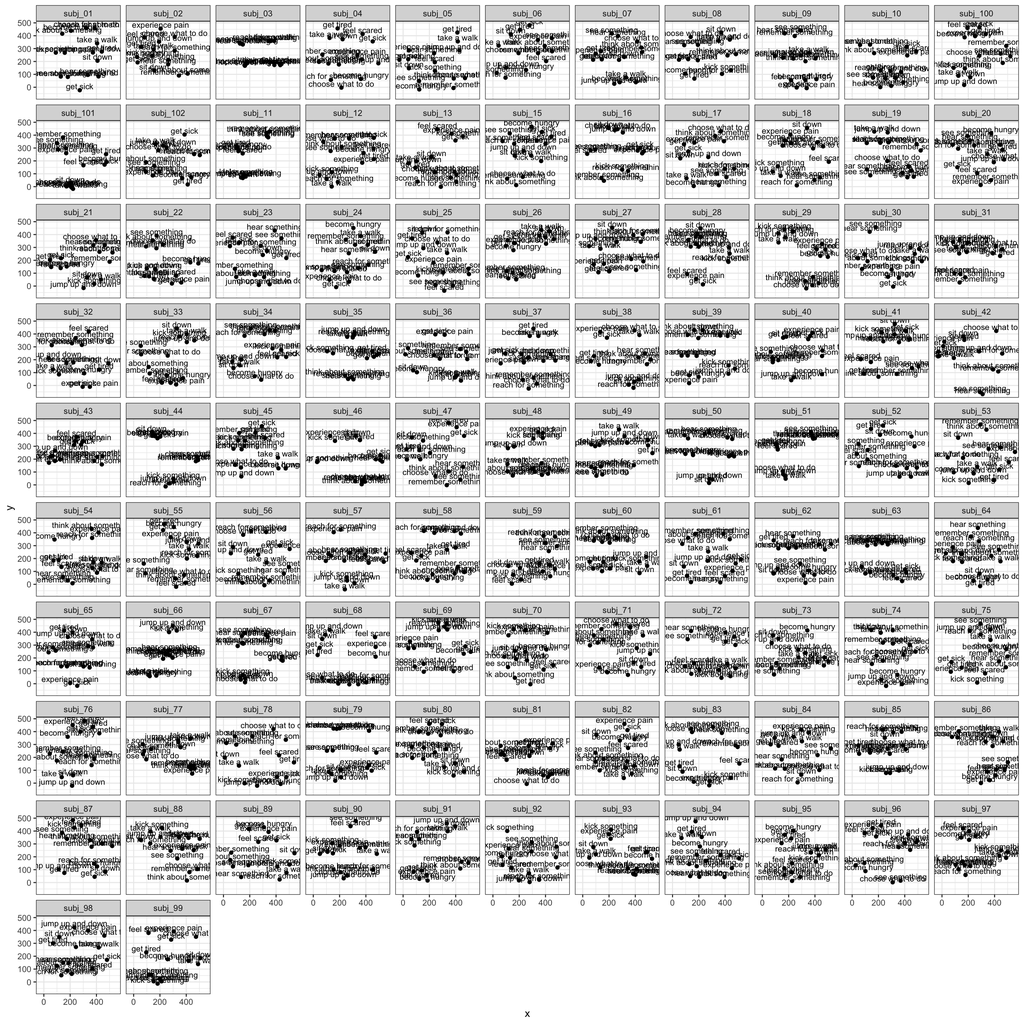

```r
d %>%
  filter(trial_type == "free_sort") %>%
  # filter(subject_id == "subj_03") %>%
  mutate(y = 500 - y) %>% #invert y axis
  ggplot(aes(x = x, y = y)) +
  geom_point() +
  geom_text(aes(label = item), size = 3, vjust = -.2) +
  facet_wrap(~subject_id)
```

## 3.2 Figure: Mean raw responses

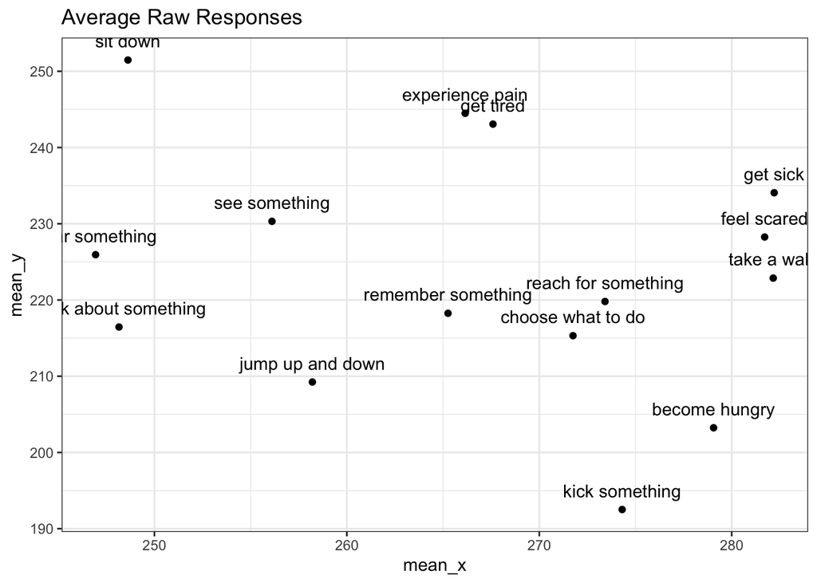

```r
# pdf("my_plot_average.pdf", width = 7, height = 4)  # Width and height are in inches
d %>%
  filter(trial_type == "free_sort") %>%
  mutate(y = 500 - y) %>%
  group_by(item) %>%
  mutate(mean_x = mean(x),
            mean_y = mean(y)) %>%
  ungroup() %>%
  distinct(item, .keep_all = TRUE) %>%
  select(-subject_id) %>%
  ggplot(aes(x = mean_x, y = mean_y)) +
  geom_point() +
  geom_text(aes(label = item), vjust = -1) +
  labs(title = "Average Raw Responses")
```

## 3.3 Figure: Subjectwise Sorting RDMs

```r
plot_rdm <- function(data, subject, desired_order) {
  df_matrix <- data %>%
    filter(subject_id == subject) %>%
    select(-subject_id) %>%
    select(itemA, itemB, freesort_distance) %>%
    pivot_wider(names_from = itemB, values_from = freesort_distance) %>%
    column_to_rownames("itemA")

  df_matrix <- df_matrix[desired_order, desired_order]
  diag(df_matrix) <- 0

  custom_palette <- colorRampPalette(c("red", "white", "blue"))(200)  # Generate 200 color levels

  corrplot(as.matrix(df_matrix), method = "color", is.corr = FALSE,
    col = custom_palette,  # Apply custom colors
    tl.col = "black", title = paste("Freesort RDM - ", subject),
    mar = c(0, 0, 2, 0), addgrid.col = "darkgray"
  )
}

subject_ids <- unique(df_freesort$subject_id)

#generate plots
# plots <- map(subject_ids, ~plot_rdm(df_freesort, .x, desired_order)) #run this to visualize plots in markdown  output

#save plots with subject name as file name
new_names <- paste0("subj_", str_pad(seq_along(subject_ids), width = 2, pad = "0"))

#loop to save each plot as a separate PDF
for (i in seq_along(subject_ids)) {
  pdf(file = paste0(base_path, "/figures/freesort/", new_names[i], ".pdf"), width = 8, height = 6)  #open a PDF device
  plot_rdm(df_freesort, subject_ids[i], desired_order)
  dev.off()  #close the device to save the file
}
```

## 3.4 Figure: Mean freesort rdm

```r
df_mean_freesort <- df_freesort %>%
  unite("item_pairs", itemA, itemB, sep = "_", remove = FALSE) %>%
  group_by(item_pairs) %>%
  mutate(mean_freesort_distance = mean(freesort_distance)) %>%
  ungroup()

# matrixify and plot
df_mean_freesort_rdm <- df_mean_freesort %>%
  distinct(item_pairs, .keep_all = TRUE) %>%
  select(itemA, itemB, mean_freesort_distance) %>%
  pivot_wider(names_from = itemB, values_from = mean_freesort_distance) %>%
  column_to_rownames("itemA")

df_mean_freesort_rdm <- df_mean_freesort_rdm[desired_order, desired_order]

diag(df_mean_freesort_rdm) <- NA #set diagonals

#min max normalize
df_mean_freesort_matrix <- as.matrix(df_mean_freesort_rdm)
min_val <- min(df_mean_freesort_matrix, na.rm = TRUE)
max_val <- max(df_mean_freesort_matrix, na.rm = TRUE)
df_mean_freesort_matrix <- (df_mean_freesort_matrix - min_val) / (max_val - min_val)

group_colors <- c("#db9728", "#d0495a", "#00788a")


my_cols <- brewer.pal(11, "RdBu")

#map each item to a color based on its group
# item_colors <- setNames(c(rep(group_colors[1], 5),
#                           rep(group_colors[2], 5),
#                           rep(group_colors[3], 5)),
#                         desired_order)

#ensure colors align with the matrix order
# label_colors <- item_colors[rownames(df_mean_freesort_matrix)]

custom_palette <- colorRampPalette(c("#5E0E20", "white", "#132F5E"))

# pdf(file = paste0(rdms_outputs_path, "/freesort/averageFreesortRDM.pdf"), width = 12, height = 12)

# pdf(file = paste0(rdms_outputs_path, "/freesort/averageFreesortRDM.pdf"), width = 12, height = 12)
#
# cairo_pdf(file = paste0(rdms_outputs_path, "/freesort/averageFreesortRDM.pdf"),
#           width = 12, height = 12, bg = "transparent")

# png(file = paste0(rdms_outputs_path, "/freesort/averageFreesortRDM.png"), width = 12, height = 12, bg = "transparent")  # For raster


png(
  file = paste0(rdms_outputs_path, "/freesort/averageFreesortRDM.png"),
  width = 12,
  height = 12,
  units = "in",
  res = 300,
  bg = "transparent"
)

#large image
corrplot(
  df_mean_freesort_matrix,
  method = "color",
  is.corr = FALSE,
  col = brewer.pal(11, "RdBu"),
  # tl.col = label_colors, #to add color to axis text labels
  tl.col = "black",
  tl.cex = 2,
  na.label = "square",
  na.label.col = "darkgrey",
  mar = c(0, 0, 2, 0),
  # addgrid.col = "darkgray",
  addgrid.col = "grey65",
  cl.offset = 1.0,  # Push labels even further
  cl.cex = 2,     # Slightly smaller label text
  cl.ratio = 0.22,   # Widen the legend bar. Change this to push words far away
  cex.main = 3
)

#run this with the above to include legend for the domain colors
legend(
  "topleft",
  inset = c(0.1, 0.1), #move the legend outside the plot
  legend = c("Mind", "Action", "Body"),
  fill = group_colors,
  border = NA,
  bty = "n", #no box around the legend
  cex = 2, #text size
  xpd = TRUE, #allow drawing outside the plot area
  #ncol = 1,
  y.intersp = 1.4 #increase this for more space between rows
)
```

## 3.5 Specific freesort relations reported in paper

```r
compute_ci_freesort <- function(df, condition_label) {
  mean_distance <- mean(df$freesort_distance, na.rm = TRUE)
  sem <- sd(df$freesort_distance, na.rm = TRUE) / sqrt(nrow(df))
  ci_lower <- mean_distance - qt(0.975, df = nrow(df) - 1) * sem
  ci_upper <- mean_distance + qt(0.975, df = nrow(df) - 1) * sem

  cat(sprintf("%s: mean distance = %.3f [95%% CI: %.3f, %.3f]\n",
              condition_label, mean_distance, ci_lower, ci_upper))
}

#compute and print within domain similarities
compute_ci_freesort(df_freesort %>% filter(domain_itemA == "mind", domain_itemB == "mind"), "mind → mind")
```

```
## mind → mind: mean distance = 0.327 [95% CI: 0.315, 0.340]
```

```r
compute_ci_freesort(df_freesort %>% filter(domain_itemA == "action", domain_itemB == "action"), "action → action")
```

```
## action → action: mean distance = 0.346 [95% CI: 0.332, 0.359]
```

```r
compute_ci_freesort(df_freesort %>% filter(domain_itemA == "bio", domain_itemB == "bio"), "bio → bio")
```

```
## bio → bio: mean distance = 0.342 [95% CI: 0.329, 0.355]
```

```r
#compute and print cross domain similarities
compute_ci_freesort(df_freesort %>% filter(domain_itemA == "action", domain_itemB == "mind"), "mind → mind")
```

```
## mind → mind: mean distance = 0.545 [95% CI: 0.535, 0.555]
```

```r
compute_ci_freesort(df_freesort %>% filter(domain_itemA == "bio", domain_itemB == "mind"), "action → action")
```

```
## action → action: mean distance = 0.574 [95% CI: 0.565, 0.584]
```

```r
compute_ci_freesort(df_freesort %>% filter(domain_itemA == "bio", domain_itemB == "action"), "bio → bio")
```

```
## bio → bio: mean distance = 0.557 [95% CI: 0.547, 0.566]
```

```r
compute_ci_freesort(df_freesort %>% filter(domain_itemA == "mind", domain_itemB == "action"), "bio → bio")
```

```
## bio → bio: mean distance = 0.545 [95% CI: 0.535, 0.555]
```

```r
compute_ci_freesort(df_freesort %>% filter(domain_itemA == "mind", domain_itemB == "bio"), "bio → bio")
```

```
## bio → bio: mean distance = 0.574 [95% CI: 0.565, 0.584]
```

```r
compute_ci_freesort(df_freesort %>% filter(domain_itemA == "action", domain_itemB == "bio"), "bio → bio")
```

```
## bio → bio: mean distance = 0.557 [95% CI: 0.547, 0.566]
```

```r
#average cross-domain similarity
(.565 + .574 + .582 + .565 + .574 + .583) / 6
```

```
## [1] 0.5738333
```

```r
#average within domain similarity
(.355 + .37 + .368) / 3
```

```
## [1] 0.3643333
```

```r
#feeling scared and physio
compute_ci_freesort(df_freesort %>% filter(domain_itemA == "bio", domain_itemB == "bio") %>% filter(itemA == "feel scared"), "scared → bio")
```

```
## scared → bio: mean distance = 0.358 [95% CI: 0.330, 0.386]
```

```r
#feeling scared and mind
compute_ci_freesort(df_freesort %>% filter(domain_itemA == "bio", domain_itemB == "mind") %>% filter(itemA == "feel scared"), "scared → mind")
```

```
## scared → mind: mean distance = 0.514 [95% CI: 0.490, 0.537]
```

```r
#all other body/physio and mind
compute_ci_freesort(df_freesort %>% filter(domain_itemA == "bio", domain_itemB == "mind") %>% filter(itemA != "feel scared"), "scared → mind")
```

```
## scared → mind: mean distance = 0.589 [95% CI: 0.579, 0.599]
```

```r
0#sitting and jumping
```

```
## [1] 0
```

```r
compute_ci_freesort(df_freesort %>% filter(itemA == "sit down") %>% filter(itemB == "jump up and down"), "sit → jump")
```

```
## sit → jump: mean distance = 0.277 [95% CI: 0.223, 0.331]
```

## 3.6 Figure: Histogram of scared sorted as mind vs as body

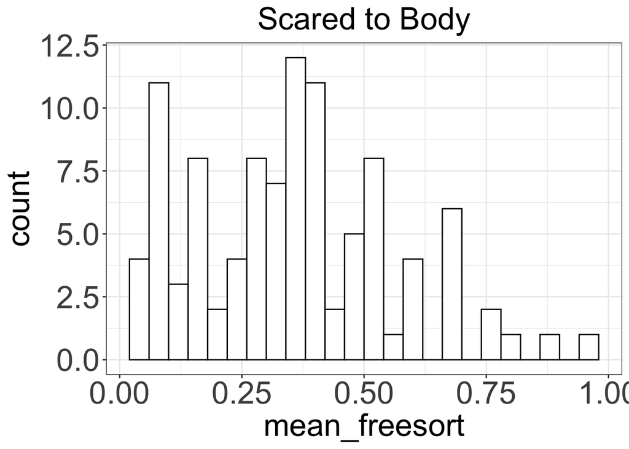

```r
#feeling scared and physio
df_freesort %>%
  mutate(subject_id = as.factor(subject_id)) %>%
  arrange(subject_id) %>%
  filter(domain_itemA == "bio", domain_itemB == "bio") %>%
  filter(itemA == "feel scared") %>%
  group_by(subject_id) %>%
  summarize(mean_freesort = mean(freesort_distance, na.rm = TRUE)) %>%
  ggplot(aes(x = mean_freesort)) +
  geom_histogram(binwidth = .04, color = "black", fill = "white") +
  labs(title = "Scared to Body") +
  theme(plot.title = element_text(size = 25, hjust = .5),
        axis.text.x = element_text(size = 25),
        axis.text.y = element_text(size = 25),
        axis.title.x = element_text(size = 25),
        axis.title.y = element_text(size = 25))
```

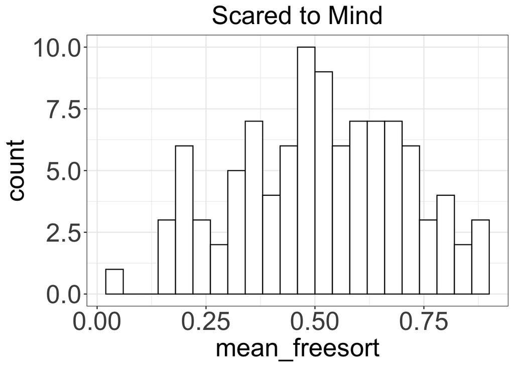

```r
#feeling scared and mind
df_freesort %>%
  mutate(subject_id = as.factor(subject_id)) %>%
  arrange(subject_id) %>%
  filter(domain_itemA == "bio", domain_itemB == "mind") %>%
  filter(itemA == "feel scared") %>%
  group_by(subject_id) %>%
  summarize(mean_freesort = mean(freesort_distance, na.rm = TRUE)) %>%
  ggplot(aes(x = mean_freesort)) +
  geom_histogram(binwidth = .04, color = "black", fill = "white") +
  labs(title = "Scared to Mind") +
  theme(plot.title = element_text(size = 25, hjust = .5),
        axis.text.x = element_text(size = 25),
        axis.text.y = element_text(size = 25),
        axis.title.x = element_text(size = 25),
        axis.title.y = element_text(size = 25))
```

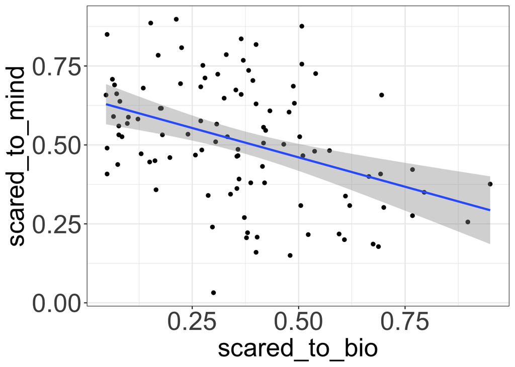

```r
# Combined scatterplot
#feeling scared and mind
df_scared_to_mind <- df_freesort %>%
  filter(domain_itemA == "bio", domain_itemB == "mind") %>%
  filter(itemA == "feel scared") %>%
  group_by(subject_id) %>%
  summarize(scared_to_mind = mean(freesort_distance, na.rm = TRUE))

df_freesort %>%
  filter(domain_itemA == "bio", domain_itemB == "bio") %>%
  filter(itemA == "feel scared") %>%
  group_by(subject_id) %>%
  summarize(scared_to_bio = mean(freesort_distance, na.rm = TRUE)) %>%
  left_join(df_scared_to_mind,
              by = "subject_id") %>%
  ggplot(aes(x = scared_to_bio, y = scared_to_mind)) +
  geom_point() +
  geom_smooth(method = "lm") +
  theme(axis.text.x = element_text(size = 25),
        axis.text.y = element_text(size = 25),
        axis.title.x = element_text(size = 25),
        axis.title.y = element_text(size = 25))
```

# 4 Causal RDMs

## 4.1 Figure: Subjectwise causal RDMs

```r
plot_causal_rdm <- function(data, subject, desired_order) {

  df_matrix <- data %>%
    filter(subject_id == subject) %>%
    select(-subject_id) %>%
    select(itemA, itemB, causal_distance) %>%
    pivot_wider(names_from = itemB, values_from = causal_distance) %>%
    column_to_rownames("itemA")

  df_matrix <- df_matrix[desired_order, desired_order]
  diag(df_matrix) <- 0

  custom_palette <- colorRampPalette(c("red", "white", "blue"))(200)


  corrplot(as.matrix(df_matrix), method = "color", is.corr = FALSE,
               col = custom_palette,  # Apply custom colors
           tl.col = "black", title = paste("Causal RDM - ", subject),
           mar = c(0, 0, 2, 0), addgrid.col = "darkgray")
}

subject_ids <- unique(df_causal$subject_id)

#generate plots
# plots <- map(subject_ids, ~plot_causal_rdm(df_causal, .x, desired_order)) #run this to generate plots

# save plots with subject name as file name
new_names <- paste0("subj_", str_pad(seq_along(subject_ids), width = 2, pad = "0"))

for (i in seq_along(subject_ids)) {
    pdf(file = paste0(base_path, "/figures/causal/", new_names[i], ".pdf"), width = 8, height = 6)
  plot_causal_rdm(df_causal, subject_ids[i], desired_order)
  dev.off()
}
```

## 4.2 Figure: Mean causal RDM

```r
df_mean_causal <- df_causal %>%
  mutate(item_pairs = str_c(itemA, itemB, sep = "-"))  %>%
  group_by(item_pairs) %>%
  mutate(mean_causal_distance = mean(causal_distance, na.rm = TRUE)) %>%  #average across participants
  ungroup()

df_mean_causal_rdm <- df_mean_causal %>%
  distinct(item_pairs, .keep_all = TRUE) %>%
  select(itemA, itemB, mean_causal_distance) %>%
  pivot_wider(names_from = itemB, values_from = mean_causal_distance) %>%
  column_to_rownames("itemA")

df_mean_causal_rdm <- df_mean_causal_rdm[desired_order, desired_order]

diag(df_mean_causal_rdm) <- NA

#min max normalize
df_mean_causal_matrix <- as.matrix(df_mean_causal_rdm)
min_val <- min(df_mean_causal_matrix, na.rm = TRUE)
max_val <- max(df_mean_causal_matrix, na.rm = TRUE)
df_mean_causal_matrix <- (df_mean_causal_matrix - min_val) / (max_val - min_val)

#colors
group_colors <- c("#db9728", "#d0495a", "#00788a")


item_colors <- setNames(c(rep(group_colors[1], 5), #mind
                          rep(group_colors[2], 5), #action
                          rep(group_colors[3], 5)), #body
                        desired_order)

label_colors <- item_colors[rownames(df_mean_causal_rdm)]

# custom_palette <- colorRampPalette(c("red", "white", "blue"))

# pdf(file = paste0(rdms_outputs_path, "/causal/averageCausalRDM.pdf"), width = 12, height = 12)

png(
  file = paste0(rdms_outputs_path, "/causal/averageCausalRDM.png"),
  width = 12,
  height = 12,
  units = "in",
  res = 300,
  bg = "transparent"
)


#large image
corrplot(
  df_mean_causal_matrix,
  method = "color",
  is.corr = FALSE,
  # col = custom_palette(200),
  col = brewer.pal(11, "RdBu"),
  tl.col = "black",
  # tl.col = label_colors,
  tl.cex = 2,
  mar = c(0, 0, 2, 0),
  addgrid.col = "darkgray",
  na.label = "square",
  na.label.col = "darkgrey",
  cl.offset = 1.0,
  cl.cex = 2, #label text
  cl.ratio = 0.22, #push words far away
  cex.main = 3
)

#run this together with above to include a domains color legend
legend(
  "topleft",
  inset = c(0.1, 0.1),
  legend = c("Mind", "Action", "Body"),
  fill = group_colors,
  border = NA,
  bty = "n",
  cex = 2, #text size
  xpd = TRUE, #draw outside the plot area
  #ncol = 1,
  y.intersp = 1.4 #more space between rows
)
```

## 4.3 Specific causal relations reported in paper

```r
#========Function========#

compute_ci <- function(df, condition_label) {
  mean_distance <- mean(df$causal_distance, na.rm = TRUE)
  sem <- sd(df$causal_distance, na.rm = TRUE) / sqrt(nrow(df))
  ci_lower <- mean_distance - qt(0.975, df = nrow(df) - 1) * sem
  ci_upper <- mean_distance + qt(0.975, df = nrow(df) - 1) * sem

  cat(sprintf("%s: mean distance = %.3f [95%% CI: %.3f, %.3f]\n",
              condition_label, mean_distance, ci_lower, ci_upper))
}

#========Mind & Action========#

#Mind → Action
compute_ci(df_causal %>% filter(domain_itemA == "mind", domain_itemB == "action"), "mind → action")
```

```
## mind → action: mean distance = 0.313 [95% CI: 0.303, 0.324]
```

```r
#Action → Mind
compute_ci(df_causal %>% filter(domain_itemA == "action", domain_itemB == "mind"), "action → mind")
```

```
## action → mind: mean distance = 0.375 [95% CI: 0.363, 0.386]
```

```r
##Effect size of Mind → Action vs Action → Mind
df_mind_to_action <- df_causal %>%
  filter(domain_itemA == "mind") %>%
  filter(domain_itemB == "action") %>%
  mutate(type = "mind_to_action") %>%
  select(subject_id, domain_itemA, domain_itemB, causal_distance, type)

df_action_to_mind <- df_causal %>%
              filter(domain_itemA == "action") %>%
              filter(domain_itemB == "mind") %>%
              mutate(type = "action_to_mind") %>%
              select(subject_id, domain_itemA, domain_itemB, causal_distance, type)

df_mind_action <- rbind(df_mind_to_action, df_action_to_mind) %>%
  mutate(type = factor(type, levels = c("mind_to_action", "action_to_mind")))

paste0("ES of walk to mind to action vs action to mind")
```

```
## [1] "ES of walk to mind to action vs action to mind"
```

```r
model_mind_action <- lmerTest::lmer(causal_distance ~ type + (1 | subject_id),
                             data = df_mind_action)

summary(model_mind_action)
```

```
## Linear mixed model fit by REML. t-tests use Satterthwaite's method [
## lmerModLmerTest]
## Formula: causal_distance ~ type + (1 | subject_id)
##    Data: df_mind_action
##
## REML criterion at convergence: 172.2
##
## Scaled residuals:
##     Min      1Q  Median      3Q     Max
## -2.7697 -0.6268 -0.1539  0.5586  3.5793
##
## Random effects:
##  Groups     Name        Variance Std.Dev.
##  subject_id (Intercept) 0.02180  0.1477
##  Residual               0.05691  0.2385
## Number of obs: 5050, groups:  subject_id, 101
##
## Fixed effects:
##                     Estimate Std. Error        df t value Pr(>|t|)
## (Intercept)        3.133e-01  1.544e-02 1.102e+02  20.293   <2e-16 ***
## typeaction_to_mind 6.128e-02  6.714e-03 4.948e+03   9.127   <2e-16 ***
## ---
## Signif. codes:  0 '***' 0.001 '**' 0.01 '*' 0.05 '.' 0.1 ' ' 1
##
## Correlation of Fixed Effects:
##             (Intr)
## typctn_t_mn -0.217
```

```r
standardize_parameters(model_mind_action)
```

```
## # Standardization method: refit
##
## Parameter             | Std. Coef. |         95% CI
## ---------------------------------------------------
## (Intercept)           |      -0.11 | [-0.22,  0.00]
## type [action_to_mind] |       0.22 | [ 0.17,  0.26]
```

```r
#========Walk & Actions vs Mind========#

#Walking → Mind
compute_ci(df_causal %>% filter(itemA == "take a walk", domain_itemB == "mind"), "walk → mind")
```

```
## walk → mind: mean distance = 0.216 [95% CI: 0.196, 0.236]
```

```r
#All other actions → Mind
compute_ci(df_causal %>% filter(itemA != "take a walk", domain_itemB == "mind"), "other actions → mind")
```

```
## other actions → mind: mean distance = 0.335 [95% CI: 0.328, 0.342]
```

```r
#Effect size of Walk → Mind vs All other actions → Mind
df_walk <- df_causal %>%
  filter(domain_itemB == "mind") %>%
  mutate(walking = ifelse(itemA == "take a walk", "walk", "not_walk"),
         walking = factor(walking, levels = c("walk", "not_walk")))

paste0("ES of Walk to Mind vs ALl other Actions to Mind")
```

```
## [1] "ES of Walk to Mind vs ALl other Actions to Mind"
```

```r
model_walk <- lmerTest::lmer(causal_distance ~ walking + (1 | subject_id),
  data = df_walk)

summary(model_walk)
```

```
## Linear mixed model fit by REML. t-tests use Satterthwaite's method [
## lmerModLmerTest]
## Formula: causal_distance ~ walking + (1 | subject_id)
##    Data: df_walk
##
## REML criterion at convergence: 1554.2
##
## Scaled residuals:
##     Min      1Q  Median      3Q     Max
## -2.7012 -0.6802 -0.1946  0.5875  3.3878
##
## Random effects:
##  Groups     Name        Variance Std.Dev.
##  subject_id (Intercept) 0.01629  0.1276
##  Residual               0.06992  0.2644
## Number of obs: 7070, groups:  subject_id, 101
##
## Fixed effects:
##                  Estimate Std. Error        df t value Pr(>|t|)
## (Intercept)     2.163e-01  1.731e-02 3.041e+02  12.492   <2e-16 ***
## walkingnot_walk 1.189e-01  1.221e-02 6.968e+03   9.734   <2e-16 ***
## ---
## Signif. codes:  0 '***' 0.001 '**' 0.01 '*' 0.05 '.' 0.1 ' ' 1
##
## Correlation of Fixed Effects:
##             (Intr)
## wlkngnt_wlk -0.655
```

```r
standardize_parameters(model_walk)
```

```
## # Standardization method: refit
##
## Parameter          | Std. Coef. |         95% CI
## ------------------------------------------------
## (Intercept)        |      -0.37 | [-0.49, -0.26]
## walking [not_walk] |       0.40 | [ 0.32,  0.48]
```

```r
#========Assorted pairs========#

compute_ci(df_causal %>% filter(domain_itemA == "action", domain_itemB == "action"), "action → action")
```

```
## action → action: mean distance = 0.557 [95% CI: 0.544, 0.571]
```

```r
compute_ci(df_causal %>% filter(domain_itemA == "bio", domain_itemB == "bio"), "body → body")
```

```
## body → body: mean distance = 0.344 [95% CI: 0.330, 0.357]
```

```r
compute_ci(df_causal %>% filter(domain_itemA == "bio", domain_itemB == "action"), "body → action")
```

```
## body → action: mean distance = 0.415 [95% CI: 0.402, 0.428]
```

```r
compute_ci(df_causal %>% filter(domain_itemA == "action", domain_itemB == "bio"), "action → body")
```

```
## action → body: mean distance = 0.406 [95% CI: 0.393, 0.418]
```

```r
#========Perception & Cognition========#

#Perception → Cognition
compute_ci(df_causal %>%
             filter(domain_itemA == "mind", domain_itemB == "mind",
                    itemA %in% c("hear something", "see something"),
                    itemB %in% c("choose what to do", "think about something", "remember something")),
           "perception → cognition")
```

```
## perception → cognition: mean distance = 0.137 [95% CI: 0.122, 0.151]
```

```r
#Cognition → Perception
compute_ci(df_causal %>%
             filter(domain_itemA == "mind", domain_itemB == "mind",
                    itemB %in% c("hear something", "see something"),
                    itemA %in% c("choose what to do", "think about something", "remember something")),
           "cognition → perception")
```

```
## cognition → perception: mean distance = 0.438 [95% CI: 0.414, 0.462]
```

```r
#Effect size of Per → Cog vs Cog to Per
df_perception_to_cognition <- df_causal %>%
  filter(domain_itemA == "mind", domain_itemB == "mind",
         itemA %in% c("hear something", "see something"),
         itemB %in% c("choose what to do", "think about something", "remember something")) %>%
  mutate(type = "perception_to_cognition") %>%
  select(subject_id, domain_itemA, domain_itemB, causal_distance, type)

df_cognition_to_perception <- df_causal %>%
  filter(domain_itemA == "mind", domain_itemB == "mind",
         itemB %in% c("hear something", "see something"),
         itemA %in% c("choose what to do", "think about something", "remember something")) %>%
  mutate(type = "cognition_to_perception") %>%
  select(subject_id, domain_itemA, domain_itemB, causal_distance, type)

df_perception_cognition <- rbind(df_perception_to_cognition, df_cognition_to_perception) %>%
  mutate(type = factor(type, levels = c("perception_to_cognition",
                                        "cognition_to_perception")))

paste0("ES of Per to Cog vs Cog to Per")
```

```
## [1] "ES of Per to Cog vs Cog to Per"
```

```r
model_perception_cognition <- lmerTest::lmer(causal_distance ~ type + (1 | subject_id),
                             data = df_perception_cognition)

summary(model_perception_cognition)
```

```
## Linear mixed model fit by REML. t-tests use Satterthwaite's method [
## lmerModLmerTest]
## Formula: causal_distance ~ type + (1 | subject_id)
##    Data: df_perception_cognition
##
## REML criterion at convergence: -103.3
##
## Scaled residuals:
##     Min      1Q  Median      3Q     Max
## -2.4917 -0.6800 -0.1316  0.4451  4.0362
##
## Random effects:
##  Groups     Name        Variance Std.Dev.
##  subject_id (Intercept) 0.01425  0.1194
##  Residual               0.04685  0.2164
## Number of obs: 1212, groups:  subject_id, 101
##
## Fixed effects:
##                              Estimate Std. Error        df t value Pr(>|t|)
## (Intercept)                 1.368e-01  1.478e-02 1.470e+02   9.253  2.4e-16 ***
## typecognition_to_perception 3.012e-01  1.243e-02 1.110e+03  24.226  < 2e-16 ***
## ---
## Signif. codes:  0 '***' 0.001 '**' 0.01 '*' 0.05 '.' 0.1 ' ' 1
##
## Correlation of Fixed Effects:
##             (Intr)
## typcgntn_t_ -0.421
```

```r
standardize_parameters(model_perception_cognition)
```

```
## # Standardization method: refit
##
## Parameter                      | Std. Coef. |         95% CI
## ------------------------------------------------------------
## (Intercept)                    |      -0.52 | [-0.62, -0.42]
## type [cognition_to_perception] |       1.04 | [ 0.96,  1.13]
```

```r
#========Other Assorted========#

#Seeing → Sick
compute_ci(df_causal %>% filter(itemA == "see something", itemB == "get sick"), "seeing → sick")
```

```
## seeing → sick: mean distance = 0.369 [95% CI: 0.303, 0.435]
```

```r
#Hearing → Sick
compute_ci(df_causal %>% filter(itemA == "hear something", itemB == "get sick"), "hearing → sick")
```

```
## hearing → sick: mean distance = 0.596 [95% CI: 0.536, 0.656]
```

```r
#Sitting → Jumping
compute_ci(df_causal %>% filter(itemA == "sit down", itemB == "jump up and down"), "sit → jump")
```

```
## sit → jump: mean distance = 0.820 [95% CI: 0.770, 0.869]
```

```r
#Jumping → Sitting
compute_ci(df_causal %>% filter(itemA == "jump up and down", itemB == "sit down"), "jump → sit")
```

```
## jump → sit: mean distance = 0.526 [95% CI: 0.459, 0.594]
```

```r
#========Walk & Actions vs Mind========#

#Walking → Mind
compute_ci(df_causal %>% filter(itemA == "take a walk", domain_itemB == "mind"), "walk → mind")
```

```
## walk → mind: mean distance = 0.216 [95% CI: 0.196, 0.236]
```

```r
#All other actions → Mind
compute_ci(df_causal %>% filter(itemA != "take a walk", domain_itemB == "mind"), "other actions → mind")
```

```
## other actions → mind: mean distance = 0.335 [95% CI: 0.328, 0.342]
```

```r
##Effect size of Walk → Mind vs All Other actions → Mind
df_walk <- df_causal %>%
  filter(domain_itemB == "mind") %>%
  mutate(walking = ifelse(itemA == "take a walk", "walk", "not_walk"),
         walking = factor(walking, levels = c("walk", "not_walk")))

model_walk <- lmerTest::lmer(causal_distance ~ walking + (1 | subject_id),
  data = df_walk)

summary(model_walk)
```

```
## Linear mixed model fit by REML. t-tests use Satterthwaite's method [
## lmerModLmerTest]
## Formula: causal_distance ~ walking + (1 | subject_id)
##    Data: df_walk
##
## REML criterion at convergence: 1554.2
##
## Scaled residuals:
##     Min      1Q  Median      3Q     Max
## -2.7012 -0.6802 -0.1946  0.5875  3.3878
##
## Random effects:
##  Groups     Name        Variance Std.Dev.
##  subject_id (Intercept) 0.01629  0.1276
##  Residual               0.06992  0.2644
## Number of obs: 7070, groups:  subject_id, 101
##
## Fixed effects:
##                  Estimate Std. Error        df t value Pr(>|t|)
## (Intercept)     2.163e-01  1.731e-02 3.041e+02  12.492   <2e-16 ***
## walkingnot_walk 1.189e-01  1.221e-02 6.968e+03   9.734   <2e-16 ***
## ---
## Signif. codes:  0 '***' 0.001 '**' 0.01 '*' 0.05 '.' 0.1 ' ' 1
##
## Correlation of Fixed Effects:
##             (Intr)
## wlkngnt_wlk -0.655
```

```r
standardize_parameters(model_walk)
```

```
## # Standardization method: refit
##
## Parameter          | Std. Coef. |         95% CI
## ------------------------------------------------
## (Intercept)        |      -0.37 | [-0.49, -0.26]
## walking [not_walk] |       0.40 | [ 0.32,  0.48]
```

```r
#========Jump & Kick vs Mind========#

#Jumping → Mind
compute_ci(df_causal %>% filter(itemA == "jump up and down", domain_itemB == "mind"), "jump → mind")
```

```
## jump → mind: mean distance = 0.479 [95% CI: 0.451, 0.506]
```

```r
#Kicking → Mind
compute_ci(df_causal %>% filter(itemA == "kick something", domain_itemB == "mind"), "jump → mind")
```

```
## jump → mind: mean distance = 0.424 [95% CI: 0.397, 0.451]
```

```r
#=======Causal Promiscuity Across Domains========#

#Mind -> All
compute_ci(df_causal %>% filter(domain_itemA == "mind"), "mind → all")
```

```
## mind → all: mean distance = 0.313 [95% CI: 0.306, 0.319]
```

```r
#Action -> All
compute_ci(df_causal %>% filter(domain_itemA == "action"), "action → all")
```

```
## action → all: mean distance = 0.438 [95% CI: 0.431, 0.445]
```

```r
#Bio -> All
compute_ci(df_causal %>% filter(domain_itemA == "bio"), "bio → all")
```

```
## bio → all: mean distance = 0.366 [95% CI: 0.359, 0.374]
```

```r
#effect size: mind vs action vs bio
df_from_three_way <- df_causal %>%
  mutate(domain_source = domain_itemA) %>%
  mutate(domain_source = factor(domain_source, levels = c("mind", "action", "bio")))

model_from_three_way <- lmerTest::lmer(causal_distance ~ domain_source + (1|subject_id),
                     data = df_from_three_way)
summary(model_from_three_way)
```

```
## Linear mixed model fit by REML. t-tests use Satterthwaite's method [
## lmerModLmerTest]
## Formula: causal_distance ~ domain_source + (1 | subject_id)
##    Data: df_from_three_way
##
## REML criterion at convergence: 6528.4
##
## Scaled residuals:
##     Min      1Q  Median      3Q     Max
## -2.6939 -0.7137 -0.1839  0.7048  3.0927
##
## Random effects:
##  Groups     Name        Variance Std.Dev.
##  subject_id (Intercept) 0.01726  0.1314
##  Residual               0.07812  0.2795
## Number of obs: 21210, groups:  subject_id, 101
##
## Fixed effects:
##                      Estimate Std. Error        df t value Pr(>|t|)
## (Intercept)         3.127e-01  1.349e-02 1.086e+02   23.18   <2e-16 ***
## domain_sourceaction 1.253e-01  4.701e-03 2.111e+04   26.66   <2e-16 ***
## domain_sourcebio    5.369e-02  4.701e-03 2.111e+04   11.42   <2e-16 ***
## ---
## Signif. codes:  0 '***' 0.001 '**' 0.01 '*' 0.05 '.' 0.1 ' ' 1
##
## Correlation of Fixed Effects:
##             (Intr) dmn_srcc
## domn_srcctn -0.174
## domain_srcb -0.174  0.500
```

```r
##standardized betas
standardize_parameters(model_from_three_way)
```

```
## # Standardization method: refit
##
## Parameter              | Std. Coef. |         95% CI
## ----------------------------------------------------
## (Intercept)            |      -0.19 | [-0.28, -0.11]
## domain source [action] |       0.40 | [ 0.37,  0.43]
## domain source [bio]    |       0.17 | [ 0.14,  0.20]
```

```r
#effect size 2: mind vs mean od bio and action
df_from_two_way <- df_causal %>%
  mutate(domain_source = domain_itemA) %>%
  mutate(domain_source = ifelse(domain_itemA == "mind", "mind", "other")) %>%
  mutate(domain_source = factor(domain_source, levels = c("mind", "other")))

model_from_two_way <- lmerTest::lmer(causal_distance ~ domain_source + (1|subject_id),
                     data = df_from_two_way)
summary(model_from_two_way)
```

```
## Linear mixed model fit by REML. t-tests use Satterthwaite's method [
## lmerModLmerTest]
## Formula: causal_distance ~ domain_source + (1 | subject_id)
##    Data: df_from_two_way
##
## REML criterion at convergence: 6750.5
##
## Scaled residuals:
##     Min      1Q  Median      3Q     Max
## -2.5516 -0.7107 -0.1810  0.7075  3.1591
##
## Random effects:
##  Groups     Name        Variance Std.Dev.
##  subject_id (Intercept) 0.01726  0.1314
##  Residual               0.07898  0.2810
## Number of obs: 21210, groups:  subject_id, 101
##
## Fixed effects:
##                     Estimate Std. Error        df t value Pr(>|t|)
## (Intercept)        3.127e-01  1.349e-02 1.087e+02   23.18   <2e-16 ***
## domain_sourceother 8.951e-02  4.093e-03 2.111e+04   21.87   <2e-16 ***
## ---
## Signif. codes:  0 '***' 0.001 '**' 0.01 '*' 0.05 '.' 0.1 ' ' 1
##
## Correlation of Fixed Effects:
##             (Intr)
## domn_srcthr -0.202
```

```r
##standardized betas
standardize_parameters(model_from_two_way)
```

```
## # Standardization method: refit
##
## Parameter             | Std. Coef. |         95% CI
## ---------------------------------------------------
## (Intercept)           |      -0.19 | [-0.28, -0.11]
## domain source [other] |       0.29 | [ 0.26,  0.31]
```

```r
#===========Mind & Bio===========#

#Mind -> Bio
compute_ci(df_causal %>% filter(domain_itemA == "mind", domain_itemB == "bio"), "mind → bio")
```

```
## mind → bio: mean distance = 0.358 [95% CI: 0.346, 0.370]
```

```r
#Bio -> Mind
compute_ci(df_causal %>% filter(domain_itemA == "bio", domain_itemB == "mind"), "bio → mind")
```

```
## bio → mind: mean distance = 0.336 [95% CI: 0.324, 0.347]
```

```r
#===========Body to Cog vs Body to Percep and Body to Action===========#

#Bio -> Cog
compute_ci(df_causal %>%
             filter(domain_itemA == "bio", domain_itemB == "mind",
                    itemB %in% c("choose what to do", "think about something", "remember something")),
           "bio → cognition")
```

```
## bio → cognition: mean distance = 0.243 [95% CI: 0.231, 0.255]
```

```r
#Bio -> Per
compute_ci(df_causal %>%
             filter(domain_itemA == "bio", domain_itemB == "mind",
                    itemB %in% c("see something", "hear something")),
           "bio → perception")
```

```
## bio → perception: mean distance = 0.474 [95% CI: 0.455, 0.494]
```

```r
#Bio -> Action
compute_ci(df_causal %>% filter(domain_itemA == "bio", domain_itemB == "action"), "bio → action")
```

```
## bio → action: mean distance = 0.415 [95% CI: 0.402, 0.428]
```

```r
##Effect size of Bio -> Cog vs Bio -> Per and Bio -> Action
df_bio <- df_causal %>%
  filter(domain_itemA == "bio") %>%
  mutate(effect_type = case_when(
      itemB %in% c("choose what to do",
                   "think about something",
                   "remember something") ~ "cognitive",
      itemB %in% c("see something", "hear something") ~ "perceptual",
      domain_itemB == "action" ~ "action",
      TRUE ~ NA_character_),
    effect_type = factor(effect_type, levels = c("cognitive", "perceptual", "action"))
  ) %>%
  filter(!is.na(effect_type))

model_bio_targets <- lmerTest::lmer(causal_distance ~ effect_type + (1 | subject_id),
  data = df_bio
)
summary(model_bio_targets)
```

```
## Linear mixed model fit by REML. t-tests use Satterthwaite's method [
## lmerModLmerTest]
## Formula: causal_distance ~ effect_type + (1 | subject_id)
##    Data: df_bio
##
## REML criterion at convergence: 1433.8
##
## Scaled residuals:
##     Min      1Q  Median      3Q     Max
## -2.7215 -0.7236 -0.1342  0.6894  2.6656
##
## Random effects:
##  Groups     Name        Variance Std.Dev.
##  subject_id (Intercept) 0.01834  0.1354
##  Residual               0.07356  0.2712
## Number of obs: 5050, groups:  subject_id, 101
##
## Fixed effects:
##                        Estimate Std. Error        df t value Pr(>|t|)
## (Intercept)           2.431e-01  1.517e-02 1.376e+02   16.02   <2e-16 ***
## effect_typeperceptual 2.314e-01  1.102e-02 4.947e+03   21.00   <2e-16 ***
## effect_typeaction     1.721e-01  8.814e-03 4.947e+03   19.52   <2e-16 ***
## ---
## Signif. codes:  0 '***' 0.001 '**' 0.01 '*' 0.05 '.' 0.1 ' ' 1
##
## Correlation of Fixed Effects:
##             (Intr) effct_typp
## effct_typpr -0.290
## effct_typct -0.363  0.500
```

```r
standardize_parameters(model_bio_targets)
```

```
## # Standardization method: refit
##
## Parameter                | Std. Coef. |         95% CI
## ------------------------------------------------------
## (Intercept)              |      -0.42 | [-0.51, -0.32]
## effect type [perceptual] |       0.73 | [ 0.66,  0.80]
## effect type [action]     |       0.54 | [ 0.49,  0.60]
```

```r
#===========Action, Cog & Per===========#

#Action -> Cog
compute_ci(df_causal %>%
             filter(domain_itemA == "action", domain_itemB == "mind",
                    itemB %in% c("choose what to do", "think about something", "remember something")),
           "action → cognition")
```

```
## action → cognition: mean distance = 0.358 [95% CI: 0.344, 0.373]
```

```r
#Action -> Per
compute_ci(df_causal %>%
             filter(domain_itemA == "action", domain_itemB == "mind",
                    itemB %in% c("see something", "hear something")),
           "action → perception")
```

```
## action → perception: mean distance = 0.399 [95% CI: 0.380, 0.418]
```

# 5 NB: Maybe move this to causal signatures script?

## 5.1 Figure: For Causal Signatures SPP 2026

For the causal signatures Spp paper. Figure for comparing adult responses to kid responses.

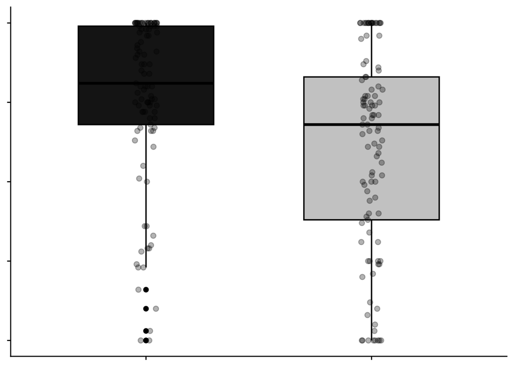

```r
fig_causal_sig <- d %>%
  filter(trial_type == "causation",
         !attention_check,
         itemA != itemB,
         itemA == "see something",
         itemB %in% c("become hungry", "experience pain")) %>%
  mutate(item_pairs = str_c(itemA, itemB, sep = "-")) %>%
  ggplot(aes(x = item_pairs, y = response, fill = item_pairs)) +
  geom_boxplot(color = "black",
               width = 0.6) +
  geom_jitter(width = 0.05, height = 0,
              alpha = 0.3, size = 2) +
  labs(x = "Item Pair",
       y = "Response") +
  theme_cowplot() +
  scale_fill_manual(values = c( "grey10", "grey80")) +
  scale_x_discrete(labels = c("see something-become hungry" =
                                "See Something \n\nBecome Hungry",
                              "see something-experience pain" =
                                "See Something \n\nExperience Pain")) +
  theme(
    axis.text.x = element_blank(),
    axis.title.x = element_blank(),
    axis.text.y = element_blank(),
    axis.title.y = element_blank(),
    legend.position = "none"
  )

fig_causal_sig
```

```r
ggsave("causal_signatures_fig/fig_causal_sig.pdf",
       fig_causal_sig,
       width = 5,
       height = 5.5,
       unit = "in",
       bg = "white"
       )
```

## 5.2 Stats: For Causal Signatures SPP 2026

```r
d %>%
  filter(trial_type == "causation",
         !attention_check,
         itemA != itemB,
         itemA == "see something",
         itemB %in% c("become hungry", "experience pain")) %>%
  mutate(item_pairs = str_c(itemA, itemB, sep = "-")) %>%
  group_by(item_pairs) %>%
  summarize(mean_resp = mean(response),
            sd_resp = sd(response))
```

```
## # A tibble: 2 × 3
##   item_pairs                    mean_resp sd_resp
##   <chr>                             <dbl>   <dbl>
## 1 see something-become hungry        76.3    26.8
## 2 see something-experience pain      60.2    31.8
```

```r
library(lme4)
library(lmerTest)

d_sub <- d %>%
  filter(
    trial_type == "causation",
    !attention_check,
    itemA == "see something",
    itemB %in% c("become hungry", "experience pain")) %>%
  mutate(itemB = factor(itemB, levels = c("experience pain", "become hungry")),
         subject_id = factor(subject_id))

model_pain_hungry <- lmerTest::lmer(
  response ~ itemB + (1 | subject_id),
  data = d_sub)

summary(model_pain_hungry)
```

```
## Linear mixed model fit by REML. t-tests use Satterthwaite's method [
## lmerModLmerTest]
## Formula: response ~ itemB + (1 | subject_id)
##    Data: d_sub
##
## REML criterion at convergence: 1922
##
## Scaled residuals:
##     Min      1Q  Median      3Q     Max
## -2.3630 -0.4070  0.2525  0.6080  1.6360
##
## Random effects:
##  Groups     Name        Variance Std.Dev.
##  subject_id (Intercept) 231.5    15.21
##  Residual               634.0    25.18
## Number of obs: 202, groups:  subject_id, 101
##
## Fixed effects:
##                    Estimate Std. Error      df t value Pr(>|t|)
## (Intercept)          60.178      2.927 186.648  20.558  < 2e-16 ***
## itemBbecome hungry   16.139      3.543 100.000   4.555 1.48e-05 ***
## ---
## Signif. codes:  0 '***' 0.001 '**' 0.01 '*' 0.05 '.' 0.1 ' ' 1
##
## Correlation of Fixed Effects:
##             (Intr)
## itmBbcmhngr -0.605
```

## 5.3 Figure 2: For Causal signatures SPP 2026

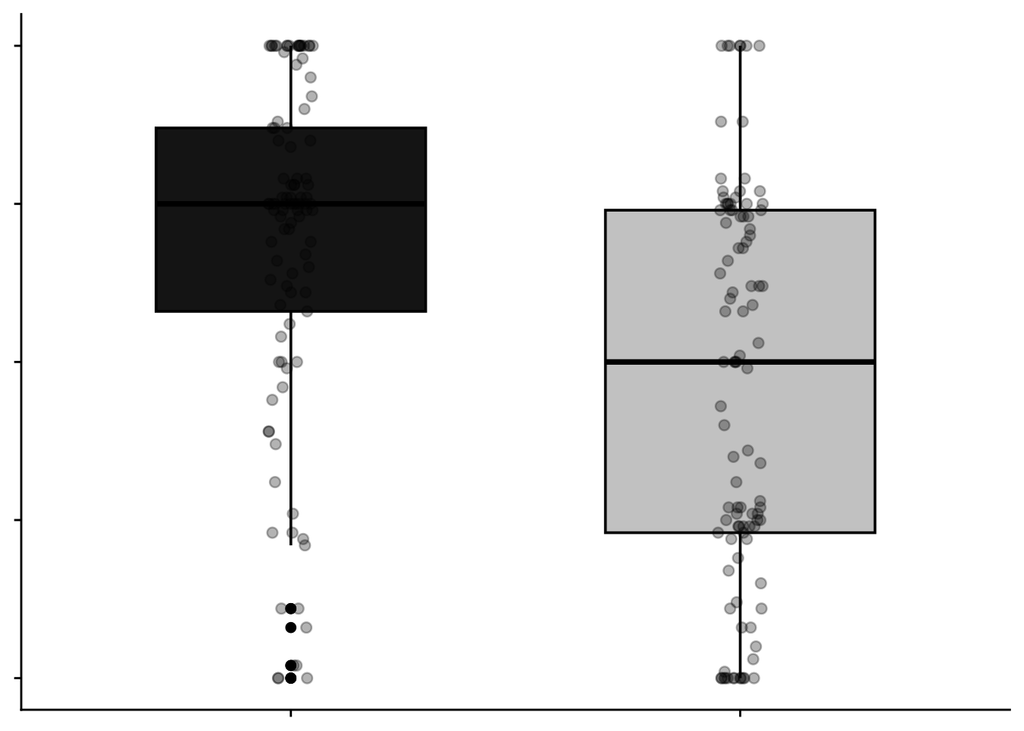

```r
fig_causal_sig_2 <- d %>%
  filter(trial_type == "causation",
         !attention_check,
         itemA != itemB,
         itemA %in% c("see something", "kick something"),
         itemB %in% c("kick something", "see something")) %>%
  mutate(item_pairs = str_c(itemA, itemB, sep = "-")) %>%
  mutate(item_pairs = factor(item_pairs,
                           levels = c("see something-kick something",
                                      "kick something-see something"))) %>%
  ggplot(aes(x = item_pairs, y = response, fill = item_pairs)) +
  geom_boxplot(color = "black", width = 0.6) +
  geom_jitter(width = 0.05, height = 0,
              alpha = 0.3, size = 2) +
  labs(x = "Item Pair",
       y = "Response") +
  theme_cowplot() +
  scale_fill_manual(values = c( "grey10", "grey80")) +
  theme(
    axis.text.x = element_blank(),
    axis.title.x = element_blank(),
    axis.text.y = element_blank(),
    axis.title.y = element_blank(),
    legend.position = "none"
  )

fig_causal_sig_2
```

```r
ggsave("causal_signatures_fig/fig_causal_sig_2.pdf",
       fig_causal_sig_2,
       width = 5,
       height = 5.5,
       unit = "in",
       bg = "white"
       )
```

# 6 Correlations: Sorting vs Causal Task

## 6.1 Mean within-subject correlation

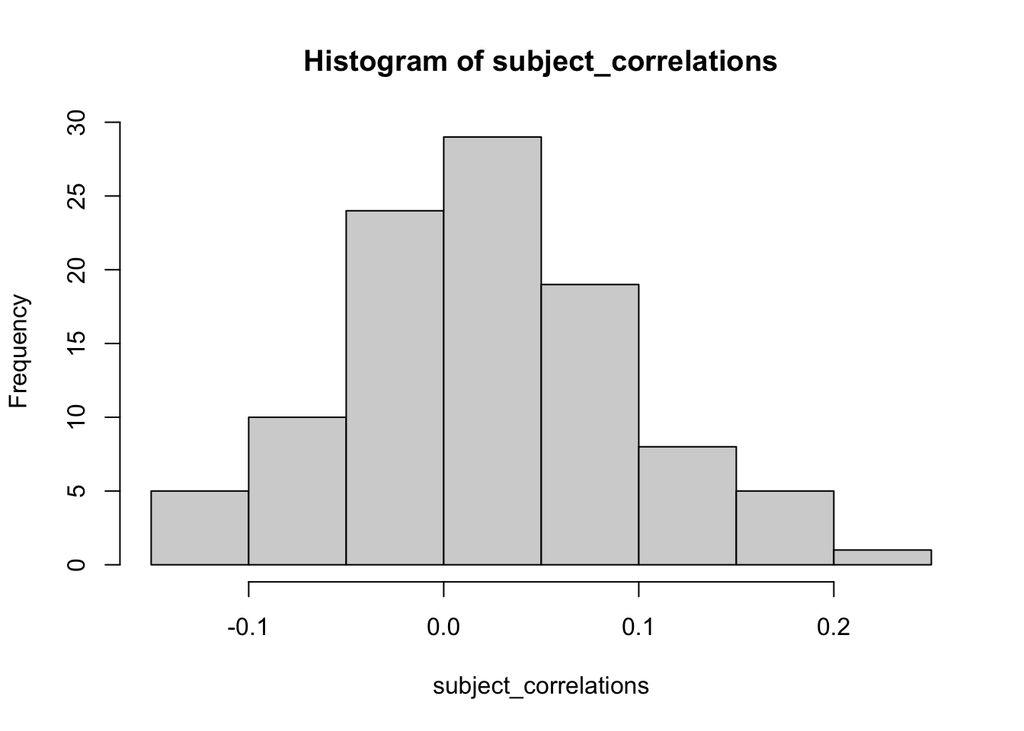

```r
compute_subjectwise_rdm_correlation <- function(df_causal, df_freesort, desired_order, metric = "kendall") {
  subject_ids <- unique(df_causal$subject_id)
  subject_correlations <- numeric(length(subject_ids))

  for (i in seq_along(subject_ids)) {
    subject <- subject_ids[i]

    freesort_rdm <- df_freesort %>%
      filter(subject_id == subject) %>%
      select(itemA, itemB, freesort_distance) %>%
      pivot_wider(names_from = itemB, values_from = freesort_distance) %>%
      column_to_rownames("itemA") %>%
      as.matrix()
      diag(freesort_rdm) <- NA
    freesort_rdm <- freesort_rdm[desired_order, desired_order]

    causal_rdm <- df_causal %>%
      filter(subject_id == subject) %>%
      select(itemA, itemB, causal_distance) %>%
      pivot_wider(names_from = itemB, values_from = causal_distance) %>%
      column_to_rownames("itemA") %>%
      as.matrix()
        diag(causal_rdm) <- NA
    causal_rdm <- causal_rdm[desired_order, desired_order]

    freesort_flat <- as.numeric(freesort_rdm)
    causal_flat <- as.numeric(causal_rdm)

    subject_correlations[i] <- cor(freesort_flat, causal_flat, method = metric, use = "complete.obs")
  }

  return(subject_correlations)
}

subject_correlations <- compute_subjectwise_rdm_correlation(df_causal, df_freesort, desired_order)
hist(subject_correlations)
```

```r
mean_correlation <- mean(subject_correlations, na.rm = TRUE)
mean_correlation
```

```
## [1] 0.01923499
```

## 6.2 t-test

```r
t_test_result <- t.test(subject_correlations, mu = 0)
t_test_result
```

```
##
##  One Sample t-test
##
## data:  subject_correlations
## t = 2.5986, df = 100, p-value = 0.01077
## alternative hypothesis: true mean is not equal to 0
## 95 percent confidence interval:
##  0.004549619 0.033920370
## sample estimates:
##  mean of x
## 0.01923499
```

## 6.3 t-test assumptions

seem fine, so no need for perm test

```r
shapiro_result <- shapiro.test(subject_correlations)
print(shapiro_result)
```

```
##
##  Shapiro-Wilk normality test
##
## data:  subject_correlations
## W = 0.98812, p-value = 0.5097
```

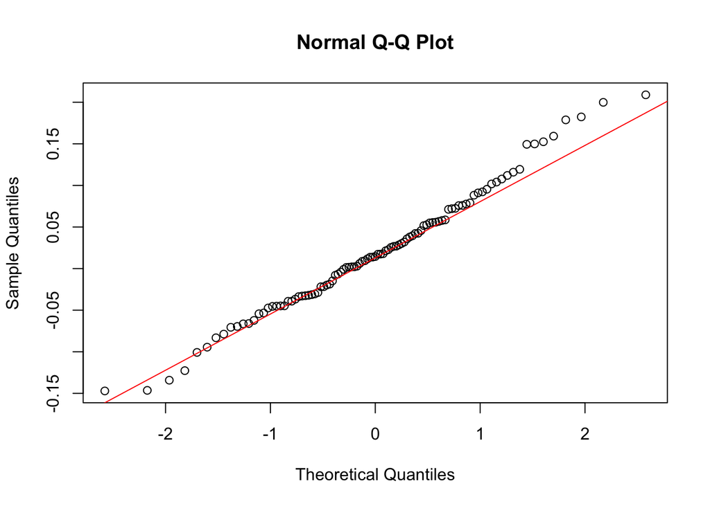

```r
qqnorm(subject_correlations)
qqline(subject_correlations, col = "red")
```

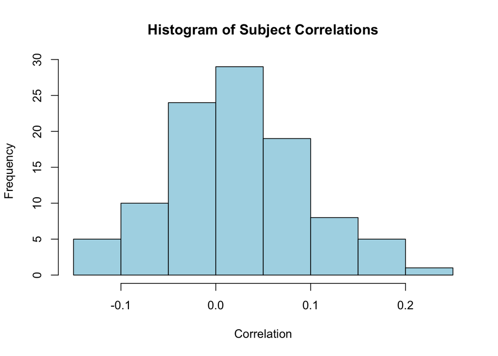

```r
hist(subject_correlations, main = "Histogram of Subject Correlations",
     xlab = "Correlation", col = "lightblue", border = "black")
```

## 6.4 Correlation between mean rdms

Note that this shows mean rdms are uncorrelated, while previously, we have seen a small positive correlation when we run subject-level correlations

```r
#using Pearson's correlation (non-significant)
mean_rdm_correlations <- cor(as.numeric(df_mean_freesort_matrix),
                             as.numeric(df_mean_causal_matrix),
                             method = "pearson", use = "complete.obs")
cor.test(as.numeric(df_mean_freesort_matrix),
         as.numeric(df_mean_causal_matrix),
         method = "pearson",
         use = "complete.obs")
```

```
##
##  Pearson's product-moment correlation
##
## data:  as.numeric(df_mean_freesort_matrix) and as.numeric(df_mean_causal_matrix)
## t = 0.68869, df = 208, p-value = 0.4918
## alternative hypothesis: true correlation is not equal to 0
## 95 percent confidence interval:
##  -0.08826296  0.18191314
## sample estimates:
##        cor
## 0.04769746
```

```r
#using Kendall's correlation (also non-significant)
n_permutations <- 10000
observed_tau <- cor(as.numeric(df_mean_freesort_matrix),
                    as.numeric(df_mean_causal_matrix),
                    method = "kendall",
                    use = "complete.obs")
observed_tau
```

```
## [1] 0.04449228
```

```r
null_dist <- replicate(n_permutations, {
  permuted <- sample(as.numeric(df_mean_causal_matrix))
  cor(as.numeric(df_mean_freesort_matrix), permuted, method = "kendall", use = "complete.obs")
})
p_value <- mean(null_dist >= observed_tau)  #one-sided
p_value
```

```
## [1] 0.1712
```

# 7 Checkpoint: Read back in data

Can start running code at this point!

```r
df_combined <- read_csv(paste0(snapshots_output_path, "/df_combined.csv"))
df_causal <- read_csv( paste0(snapshots_output_path, "/df_causal.csv"))
df_freesort <- read_csv(paste0(snapshots_output_path, "/df_freesort.csv"))
d_model_predictions <- read_csv(model_predictions_input_path)
```

# 8 Correlations: Data vs Models

## 8.1 Noise ceiling functions

```r
calculate_freesort_noise_ceiling <- function(data, subjects, desired_order, metric = "kendall") {
  # Initialize storage for correlations
  upper_bound <- numeric(length(subjects))
  lower_bound <- numeric(length(subjects))

  for (i in seq_along(subjects)) {
    subject <- subjects[i]

    #Subject's RDM
    subject_rdm <- data %>%
        filter(subject_id == subject) %>%
        select(subject_id, itemA, itemB, freesort_distance) %>%
        pivot_wider(names_from = itemB, values_from = freesort_distance) %>%
        column_to_rownames("itemA") %>%
        as.matrix()
    subject_rdm <- subject_rdm[desired_order, desired_order]

    #Grand average RDM
    grand_avg_rdm <- data %>%
        select(subject_id, itemA, itemB, freesort_distance) %>%
        unite("item_pairs", itemA, itemB, sep = "_", remove = FALSE) %>%
        group_by(item_pairs) %>%
        mutate(freesort_distance = mean(freesort_distance)) %>%
        ungroup() %>%
        distinct(item_pairs, .keep_all = TRUE) %>%
        select(-c(item_pairs, subject_id)) %>%
        pivot_wider(names_from = itemB, values_from = freesort_distance) %>%
        column_to_rownames("itemA") %>%
        as.matrix()
    grand_avg_rdm <- grand_avg_rdm[desired_order, desired_order]

    #Other subjects' average RDM
    other_avg_rdm <- data %>%
      select(subject_id, itemA, itemB, freesort_distance) %>%
      filter(subject_id != subject) %>%
      unite("item_pairs", itemA, itemB, sep = "_", remove = FALSE) %>%
      group_by(item_pairs) %>%
      mutate(freesort_distance = mean(freesort_distance)) %>%
      ungroup() %>%
      distinct(item_pairs, .keep_all = TRUE) %>%
      select(-c(item_pairs, subject_id)) %>%
      pivot_wider(names_from = itemB, values_from = freesort_distance) %>%
      column_to_rownames("itemA") %>%
      as.matrix()
    other_avg_rdm <- other_avg_rdm[desired_order, desired_order]

    subject_upper <- as.numeric(subject_rdm[upper.tri(subject_rdm)])
    other_upper <- as.numeric(other_avg_rdm[upper.tri(other_avg_rdm)])
    grand_upper <- as.numeric(grand_avg_rdm[upper.tri(grand_avg_rdm)])

    lower_bound[i] <- cor(subject_upper, other_upper, method = metric)
    upper_bound[i] <- cor(subject_upper, grand_upper, method = metric)
  }

  # Return average bounds
  list(
    upper_bound = mean(upper_bound, na.rm = TRUE),
    lower_bound = mean(lower_bound, na.rm = TRUE)
  )
}

calculate_causal_noise_ceiling <- function(data, subjects, desired_order, metric = "kendall") {
  #Initialize storage for correlations
  upper_tri_upper_bound <- numeric(length(subjects))
  upper_tri_lower_bound <- numeric(length(subjects))

  lower_tri_upper_bound <- numeric(length(subjects))
  lower_tri_lower_bound <- numeric(length(subjects))

  #Loop through each subject
  for (i in seq_along(subjects)) {
    subject <- subjects[i]

    #subject's RDM
    subject_rdm <- data %>%
        filter(subject_id == subject) %>%
        select(subject_id, itemA, itemB, causal_distance) %>%
        pivot_wider(names_from = itemB, values_from = causal_distance) %>%
        column_to_rownames("itemA") %>%
        as.matrix()
    subject_rdm <- subject_rdm[desired_order, desired_order]

    #grand average RDM
    grand_avg_rdm <- data %>%
        select(subject_id, itemA, itemB, causal_distance) %>%
        unite("item_pairs", itemA, itemB, sep = "_", remove = FALSE) %>%
        group_by(item_pairs) %>%
        mutate(causal_distance = mean(causal_distance)) %>%
        ungroup() %>%
        distinct(item_pairs, .keep_all = TRUE) %>%
        select(-c(item_pairs, subject_id)) %>%
        pivot_wider(names_from = itemB, values_from = causal_distance) %>%
        column_to_rownames("itemA") %>%
        as.matrix()
    grand_avg_rdm <- grand_avg_rdm[desired_order, desired_order]

    #other subjects' average RDM
    other_avg_rdm <- data %>%
      select(subject_id, itemA, itemB, causal_distance) %>%
      filter(subject_id != subject) %>%
      unite("item_pairs", itemA, itemB, sep = "_", remove = FALSE) %>%
      group_by(item_pairs) %>%
      mutate(causal_distance = mean(causal_distance)) %>%
      ungroup() %>%
      distinct(item_pairs, .keep_all = TRUE) %>%
      select(-c(item_pairs, subject_id)) %>%
      pivot_wider(names_from = itemB, values_from = causal_distance) %>%
      column_to_rownames("itemA") %>%
      as.matrix()
    other_avg_rdm <- other_avg_rdm[desired_order, desired_order]

    #upper tri noise ceiling
    subject_upper <- as.numeric(subject_rdm[upper.tri(subject_rdm)])
    other_upper <- as.numeric(other_avg_rdm[upper.tri(other_avg_rdm)])
    grand_upper <- as.numeric(grand_avg_rdm[upper.tri(grand_avg_rdm)])

    upper_tri_lower_bound[i] <- cor(subject_upper, other_upper, method = metric)
    upper_tri_upper_bound[i] <- cor(subject_upper, grand_upper, method = metric)

    #lower tri noise ceiling
    subject_lower <- as.numeric(subject_rdm[lower.tri(subject_rdm)])
    other_lower <- as.numeric(other_avg_rdm[lower.tri(other_avg_rdm)])
    grand_lower <- as.numeric(grand_avg_rdm[lower.tri(grand_avg_rdm)])

    lower_tri_lower_bound[i] <- cor(subject_lower, other_lower, method = metric)
    lower_tri_upper_bound[i] <- cor(subject_lower, grand_lower, method = metric)

  }

  #return average bounds
  list(
    upper_tri_upper_bound = mean(upper_tri_upper_bound, na.rm = TRUE),
    upper_tri_lower_bound = mean(upper_tri_lower_bound, na.rm = TRUE),

    lower_tri_upper_bound = mean(lower_tri_upper_bound, na.rm = TRUE),
    lower_tri_lower_bound = mean(lower_tri_lower_bound, na.rm = TRUE)
  )
}
```

## 8.2 Rdm correlation function

```r
extract_upper_tri <- function(matrix) {
  matrix[upper.tri(matrix)]
}

compute_rdm_correlation <- function(data, emp_col, theor_col, desired_order, method = "kendall") {
  rdm1 <- data %>%
    select(itemA, itemB, {{ emp_col }}) %>%
    pivot_wider(names_from = itemB, values_from = {{ emp_col }}) %>%
    column_to_rownames("itemA") %>%
    as.matrix()

  rdm2 <- data %>%
    select(itemA, itemB, {{ theor_col }}) %>%
    pivot_wider(names_from = itemB, values_from = {{ theor_col }}) %>%
    column_to_rownames("itemA") %>%
    as.matrix()

  rdm1 <- rdm1[desired_order, desired_order]
  rdm2 <- rdm2[desired_order, desired_order]

  diag(rdm1) <- NA
  diag(rdm2) <- NA

  upper_rdm1 <- extract_upper_tri(rdm1)
  upper_rdm2 <- extract_upper_tri(rdm2)

  cor(upper_rdm1, upper_rdm2, method = method, use = "complete.obs")
}
```

## 8.3 Sorting Task noise ceiling

```r
d_freesort_correlations <- df_combined %>%
  left_join(d_model_predictions, by = c("itemA", "itemB")) %>%
  group_by(subject_id) %>%
  mutate(
    `1_Mind-Body-Action` = compute_rdm_correlation(pick(everything()), freesort_distance, `theor1_Mind-Body-Action`, desired_order),
    `2_PerCog-ObjDir-Stimulus` = compute_rdm_correlation(pick(everything()), freesort_distance, `theor2_PerCog-OdActSpAct-BodyStimBodynoStim`, desired_order),
    `3_Physical-Ethereal` = compute_rdm_correlation(pick(everything()), freesort_distance, `theor3_Physical-Ethereal`, desired_order),
    `4_cosine_similarity` = compute_rdm_correlation(pick(everything()), freesort_distance, `theor4_cosine_similarity`, desired_order),
    `5_causal_judgments` = compute_rdm_correlation(pick(everything()), freesort_distance, `causal_distance`, desired_order)
  ) %>%
  ungroup() %>%
  relocate(causal_distance, .after = "freesort_distance")

subjects_freesort <- unique(d_freesort_correlations$subject_id)
noise_ceiling_sorting <- calculate_freesort_noise_ceiling(d_freesort_correlations, subjects_freesort, desired_order)
noise_ceiling_sorting
```

```
## $upper_bound
## [1] 0.2489099
##
## $lower_bound
## [1] 0.2289891
```

## 8.4 Causal Task noise ceiling

```r
d_causal_correlations <- df_combined %>%
  left_join(d_model_predictions, by = c("itemA", "itemB")) %>%
  group_by(subject_id) %>%
  mutate(
    `1_Mind-Body-Action` = compute_rdm_correlation(pick(everything()), causal_distance, `theor1_Mind-Body-Action`, desired_order),
    `2_PerCog-ObjDir-Stimulus` = compute_rdm_correlation(pick(everything()), causal_distance, `theor2_PerCog-OdActSpAct-BodyStimBodynoStim`, desired_order),
    `3_Physical-Ethereal` = compute_rdm_correlation(pick(everything()), causal_distance, `theor3_Physical-Ethereal`, desired_order),
    `4_cosine_similarity` = compute_rdm_correlation(pick(everything()), causal_distance, `theor4_cosine_similarity`, desired_order),
    `5_causal_judgments` = compute_rdm_correlation(pick(everything()), causal_distance, `causal_distance`, desired_order)
  ) %>%
  ungroup() #%>%
  # distinct(subject_id, RDM_type, tau) #added 5/7/26

# Compute noise ceiling for all subjects
subjects_causal <- unique(d_causal_correlations$subject_id)
noise_ceiling_causal <- calculate_causal_noise_ceiling(d_causal_correlations,subjects_causal, desired_order)
noise_ceiling_causal
```

```
## $upper_tri_upper_bound
## [1] 0.4281807
##
## $upper_tri_lower_bound
## [1] 0.4204204
##
## $lower_tri_upper_bound
## [1] 0.4248409
##
## $lower_tri_lower_bound
## [1] 0.4188643
```

## 8.5 Figure: RSA Model Corrs

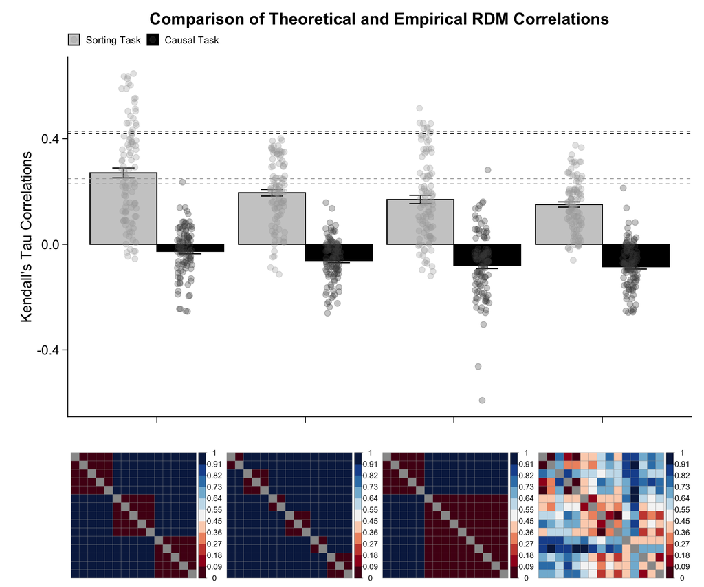

```r
aggregated_freesort_correlations <- d_freesort_correlations %>%
  rename("3 Category" = `1_Mind-Body-Action`,
         "6 Category" = `2_PerCog-ObjDir-Stimulus`,
         "2 Category" = `3_Physical-Ethereal`,
         "Cosine Similarity" = `4_cosine_similarity`) %>%
  pivot_longer(
    cols = c("2 Category", "3 Category", "6 Category", "Cosine Similarity"),
    names_to = "correlation_type",
    values_to = "correlation_value"
  ) %>%
  group_by(subject_id, correlation_type) %>%
  summarize(mean_correlation = mean(correlation_value, na.rm = TRUE), .groups = "drop") %>%
  mutate(method = "Sorting Task")

aggregated_causal_correlations <- d_causal_correlations %>%
  rename("3 Category" = `1_Mind-Body-Action`,
         "6 Category" = `2_PerCog-ObjDir-Stimulus`,
         "2 Category" = `3_Physical-Ethereal`,
         "Cosine Similarity" = `4_cosine_similarity`) %>%
  pivot_longer(
    cols = c("2 Category", "3 Category", "6 Category", "Cosine Similarity"),
    names_to = "correlation_type",
    values_to = "correlation_value"
  ) %>%
  group_by(subject_id, correlation_type) %>%
  summarize(mean_correlation = mean(correlation_value, na.rm = TRUE), .groups = "drop") %>%
  mutate(method = "Causal Task")

#combine both corrs into one
d_combined_correlations <- bind_rows(aggregated_freesort_correlations, aggregated_causal_correlations) %>%
  mutate(method = factor(method, levels = c("Sorting Task", "Causal Task")))

# d_freesort_correlations <- d_combined_correlations %>%
#   mutate(method = as.character(method)) %>%
#   filter(method == "Sorting Task")

bar_plot <- ggplot(d_combined_correlations,
                   aes(x = reorder(correlation_type, mean_correlation, FUN = function(x) -mean(x)),
                        y = mean_correlation, fill = method)) +
  stat_summary(
    fun = "mean",
    geom = "bar",
    position = "dodge",
    color = "black"
  ) +
  stat_summary(
    fun.data = mean_se,
    geom = "errorbar",
    width = 0.3,
    position = position_dodge(width = 0.9),
    color = "black"
  ) +
  geom_point(aes(color = method), alpha = 0.3, size = 3, position = position_jitterdodge(jitter.width = 0.2)) +
  scale_fill_manual(values = c("Sorting Task" = "grey80", "Causal Task" = "#000000")) + #bar fill
  scale_color_manual(values = c("Sorting Task" = "darkgray", "Causal Task" = "#4A4A4A")) + #point colors

  geom_hline(yintercept = noise_ceiling_sorting$upper_bound, color = "darkgray", linetype = "dashed", linewidth = 0.5) +
  geom_hline(yintercept = noise_ceiling_sorting$lower_bound, color = "darkgray", linetype = "dashed", linewidth = 0.5) +
  geom_hline(yintercept = noise_ceiling_causal$upper_tri_upper_bound, color = "black", linetype = "dashed", linewidth = 0.5) +
  geom_hline(yintercept = noise_ceiling_causal$upper_tri_lower_bound, color = "black", linetype = "dashed", linewidth = 0.5) +
  theme_cowplot() +
  theme(
    panel.background = element_rect(fill = NA, color = NA),
    plot.background = element_rect(fill = NA, color = NA),
    axis.text.x = element_blank(),
    axis.text.y = element_text(size = 16),
    axis.ticks.length = unit(.25, "cm"),
    axis.title.x = element_blank(),
    axis.title.y = element_text(size = 18),
    legend.position = "top",
    legend.title = element_blank(),
    plot.title = element_text(size = 20, face = "bold", hjust = 0.5),
    plot.margin = margin(t = 10, r = 10, b = 20, l = 20)
  ) +
  labs(
    y = "Kendall's Tau Correlations",
    title = "Comparison of Theoretical and Empirical RDM Correlations"
  )

# Load and create RDM images
rdm_2_category <- ggdraw() + draw_image(paste0(rdms_input_path, "/theory_4.png"), scale = 1.2)
rdm_3_category <- ggdraw() + draw_image(paste0(rdms_input_path, "/theory_2.png"), scale = 1.2)
rdm_6_category <- ggdraw() + draw_image(paste0(rdms_input_path, "/theory_3.png"), scale = 1.2)
rdm_cosine <- ggdraw() + draw_image(paste0(rdms_input_path, "/theory_1.png"), scale = 1.2)

rdm_row <- rdm_3_category + rdm_6_category + rdm_2_category + rdm_cosine +
  plot_layout(ncol = 4)
#
# plot_correlations <- bar_plot / rdm_row +
#   plot_layout(heights = c(5, 2)) #adjusts height ratio


plot_correlations <- bar_plot / rdm_row +
  plot_layout(heights = c(5, 2)) &
  theme(plot.background = element_rect(fill = NA, color = NA))

plot_correlations
```

```r
# ggsave(
#   filename = "figures/rdm_correlation_plot.pdf",
#   plot = plot_correlations,
#   device = "pdf",
#   #path = "path/to/directory",
#   width = 12,
#   height = 5,
#   units = "in"
# )

#this is the chunk to run:
ggsave(
  filename = "figures/correlations/rdm_correlation_plot.png",
  plot = plot_correlations,
  device = "png",
  width = 12,
  height = 6,
  units = "in",
  dpi = 300,
  bg = "transparent"
)
```

## 8.6 Figure: Only MAP and USE Corrs

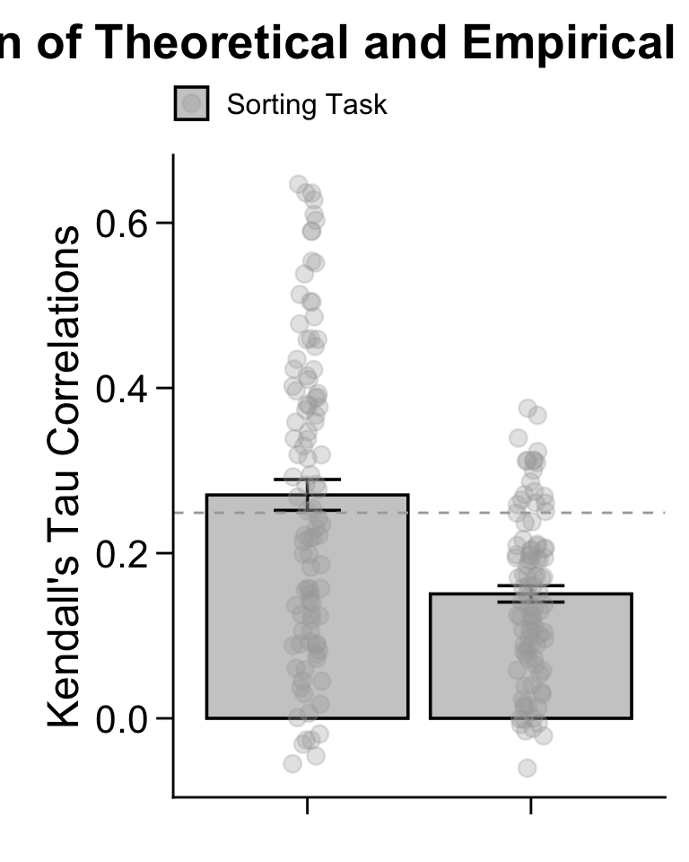

```r
#combine both corrs into one
d_combined_correlations <- bind_rows(aggregated_freesort_correlations, aggregated_causal_correlations) %>%
  mutate(method = factor(method, levels = c("Sorting Task", "Causal Task")))

d_combined_correlations_freesort <- d_combined_correlations %>%
  mutate(method = as.character(method)) %>%
  filter(method == "Sorting Task")

ggplot(d_combined_correlations_freesort %>%
         filter(correlation_type %in% c("Cosine Similarity", "3 Category")),
                   aes(x = reorder(correlation_type, mean_correlation, FUN = function(x) -mean(x)),
                        y = mean_correlation, fill = method)) +
  stat_summary(
    fun = "mean",
    geom = "bar",
    position = "dodge",
    color = "black"
  ) +
  stat_summary(
    fun.data = mean_se,
    geom = "errorbar",
    width = 0.3,
    position = position_dodge(width = 0.9),
    color = "black"
  ) +
  geom_point(aes(color = method), alpha = 0.3, size = 3, position = position_jitterdodge(jitter.width = 0.2)) +
  scale_fill_manual(values = c("Sorting Task" = "grey80", "Causal Task" = "#000000")) + #bar fill
  scale_color_manual(values = c("Sorting Task" = "darkgray", "Causal Task" = "#4A4A4A")) + #point colors

  geom_hline(yintercept = noise_ceiling_sorting$upper_bound, color = "darkgray", linetype = "dashed", linewidth = 0.5) +
  # geom_hline(yintercept = noise_ceiling_sorting$lower_bound, color = "darkgray", linetype = "dashed", linewidth = 0.5) +
  # geom_hline(yintercept = noise_ceiling_causal$upper_tri_upper_bound, color = "black", linetype = "dashed", linewidth = 0.5) +
  # geom_hline(yintercept = noise_ceiling_causal$upper_tri_lower_bound, color = "black", linetype = "dashed", linewidth = 0.5) +
  theme_cowplot() +
  theme(
    panel.background = element_rect(fill = NA, color = NA),
    plot.background = element_rect(fill = NA, color = NA),
    axis.text.x = element_blank(),
    axis.text.y = element_text(size = 16),
    axis.ticks.length = unit(.25, "cm"),
    axis.title.x = element_blank(),
    axis.title.y = element_text(size = 18),
    legend.position = "top",
    legend.title = element_blank(),
    plot.title = element_text(size = 20, face = "bold", hjust = 0.5),
    plot.margin = margin(t = 10, r = 10, b = 20, l = 20)
  ) +
  labs(
    y = "Kendall's Tau Correlations",
    title = "Comparison of Theoretical and Empirical RDM Correlations"
  )
```

## 8.7 t-tests of correlations

This compared correlations to 0.

```r
t_test_results <- d_combined_correlations %>%
  group_by(method, correlation_type) %>%
  summarise(
    mean_mean_correlation = mean(mean_correlation, na.rm = TRUE),

    test = list(t.test(mean_correlation, mu = 0)),

    t_value = test[[1]]$statistic,
    p_value = test[[1]]$p.value,
    ci_low  = test[[1]]$conf.int[1],
    ci_high = test[[1]]$conf.int[2],

    .groups = "drop"
  ) %>%
  select(-test)

print(t_test_results)
```

```
## # A tibble: 8 × 7
##   method       correlation_type  mean_mean_correlation t_value  p_value  ci_low
##   <fct>        <chr>                             <dbl>   <dbl>    <dbl>   <dbl>
## 1 Sorting Task 2 Category                       0.170    10.7  2.97e-18  0.138
## 2 Sorting Task 3 Category                       0.271    14.5  2.69e-26  0.233
## 3 Sorting Task 6 Category                       0.195    15.6  1.34e-28  0.170
## 4 Sorting Task Cosine Similarity                0.151    15.2  1.01e-27  0.131
## 5 Causal Task  2 Category                      -0.0791   -6.12 1.82e- 8 -0.105
## 6 Causal Task  3 Category                      -0.0266   -2.89 4.67e- 3 -0.0448
## 7 Causal Task  6 Category                      -0.0614   -7.50 2.63e-11 -0.0777
## 8 Causal Task  Cosine Similarity               -0.0849   -9.63 6.35e-16 -0.102
## # ℹ 1 more variable: ci_high <dbl>
```

# 9 Linear models comparing the 4 hypotheses

## 9.1 Freesort data

Reported in main paper

```r
freesort_correlations <- d_freesort_correlations %>%
  rename("mind_action_physiology_model" = `1_Mind-Body-Action`,
         "finegrained_mind_action_physiology_model" = `2_PerCog-ObjDir-Stimulus`,
         "physical_psychological_model" = `3_Physical-Ethereal`,
         "use_phrase_embeddings_model" = `4_cosine_similarity`) %>%
  pivot_longer(
    cols = c("mind_action_physiology_model":"use_phrase_embeddings_model"),
    names_to = "RDM_type",
    values_to = "tau"
  ) %>%
  select(subject_id, itemA, itemB, domain_itemA, domain_itemB,
         trial_type_order, freesort_distance, causal_distance, RDM_type, tau) %>%
  mutate(
    RDM_type = as.factor(RDM_type),
    RDM_type = relevel(RDM_type, ref = "mind_action_physiology_model")
  ) %>%
  mutate(subject_id = as.factor(subject_id)) %>%
  distinct(subject_id, RDM_type, .keep_all = TRUE) %>%
  select(subject_id, RDM_type, tau)

#Note: mind action physiology is reference model. Estimates are mean kendall's taus
model_freesort <- lmerTest::lmer(tau ~ RDM_type + (1 | subject_id),
              data = freesort_correlations)

summary(model_freesort)
```

```
## Linear mixed model fit by REML. t-tests use Satterthwaite's method [
## lmerModLmerTest]
## Formula: tau ~ RDM_type + (1 | subject_id)
##    Data: freesort_correlations
##
## REML criterion at convergence: -543.8
##
## Scaled residuals:
##      Min       1Q   Median       3Q      Max
## -2.48427 -0.63209 -0.03743  0.56577  2.76636
##
## Random effects:
##  Groups     Name        Variance Std.Dev.
##  subject_id (Intercept) 0.012645 0.11245
##  Residual               0.008937 0.09453
## Number of obs: 404, groups:  subject_id, 101
##
## Fixed effects:
##                                                   Estimate Std. Error        df
## (Intercept)                                        0.27050    0.01462 197.05395
## RDM_typefinegrained_mind_action_physiology_model  -0.07534    0.01330 300.00000
## RDM_typephysical_psychological_model              -0.10083    0.01330 300.00000
## RDM_typeuse_phrase_embeddings_model               -0.11983    0.01330 300.00000
##                                                  t value Pr(>|t|)
## (Intercept)                                       18.505  < 2e-16 ***
## RDM_typefinegrained_mind_action_physiology_model  -5.663 3.48e-08 ***
## RDM_typephysical_psychological_model              -7.580 4.35e-13 ***
## RDM_typeuse_phrase_embeddings_model               -9.008  < 2e-16 ***
## ---
## Signif. codes:  0 '***' 0.001 '**' 0.01 '*' 0.05 '.' 0.1 ' ' 1
##
## Correlation of Fixed Effects:
##             (Intr) RDM_____ RDM_t__
## RDM_typ____ -0.455
## RDM_typph__ -0.455  0.500
## RDM_typs___ -0.455  0.500    0.500
```

```r
confint(model_freesort)
```

```
## Computing profile confidence intervals ...
```

```
##                                                        2.5 %      97.5 %
## .sig01                                            0.09530581  0.13216952
## .sigma                                            0.08704529  0.10208205
## (Intercept)                                       0.24185445  0.29914962
## RDM_typefinegrained_mind_action_physiology_model -0.10136288 -0.04931064
## RDM_typephysical_psychological_model             -0.12685724 -0.07480500
## RDM_typeuse_phrase_embeddings_model              -0.14585267 -0.09380044
```

## 9.2 Freesort Model table for SI

```r
library(parameters)

model_freesort_table <- model_parameters(model_freesort,
                                         ci = 0.95,
                                         # standardize = "refit")
                                         standardize = NULL) #do not standardize
```

```
## Package 'merDeriv' needs to be installed to compute confidence intervals
##   for random effect parameters.
```

```r
model_freesort_table <- model_freesort_table %>%
  mutate(across(where(is.numeric), ~ round(.x, 2)))

model_freesort_table
```

```
## # Fixed Effects
##
## Parameter                                        | Coefficient |   SE
## ---------------------------------------------------------------------
## (Intercept)                                      |        0.27 | 0.01
## RDM_typefinegrained_mind_action_physiology_model |       -0.08 | 0.01
## RDM_typephysical_psychological_model             |       -0.10 | 0.01
## RDM_typeuse_phrase_embeddings_model              |       -0.12 | 0.01
##
## Parameter                                        |         95% CI | t(398) |      p
## -----------------------------------------------------------------------------------
## (Intercept)                                      | [ 0.24,  0.30] |  18.50 | < .001
## RDM_typefinegrained_mind_action_physiology_model | [-0.10, -0.05] |  -5.66 | < .001
## RDM_typephysical_psychological_model             | [-0.13, -0.07] |  -7.58 | < .001
## RDM_typeuse_phrase_embeddings_model              | [-0.15, -0.09] |  -9.01 | < .001
##
## # Random Effects: subject_id
##
## Parameter      | Coefficient
## ----------------------------
## SD (Intercept) |        0.11
##
## # Random Effects: Residual
##
## Parameter         | Coefficient
## -------------------------------
## SD (Observations) |        0.09
```

```r
# install.packages("flextable")
library(flextable)

model_freesort_table %>%
  flextable() %>%
  save_as_docx(path = "model_tables/model_freesort_table.docx")
```

## 9.3 Causal data

Reported in main paper

```r
causal_correlations <- d_causal_correlations %>%
  rename("mind_action_physiology_model" = `1_Mind-Body-Action`,
         "finegrained_mind_action_physiology_model" = `2_PerCog-ObjDir-Stimulus`,
         "physical_psychological_model" = `3_Physical-Ethereal`,
         "use_phrase_embeddings_model" = `4_cosine_similarity`) %>%
  pivot_longer(
    cols = c("mind_action_physiology_model":"use_phrase_embeddings_model"),
    names_to = "RDM_type",
    values_to = "tau"
  ) %>%
  select(subject_id, itemA, itemB, domain_itemA, domain_itemB, trial_type_order, freesort_distance, causal_distance, RDM_type, tau) %>%
  mutate(RDM_type = as.factor(RDM_type),
         RDM_type = relevel(RDM_type, ref = "mind_action_physiology_model")) %>%
  mutate(subject_id = as.factor(subject_id)) %>%
  distinct(subject_id, RDM_type, .keep_all = TRUE) %>% #summarize to 1 row per subject per model
  select(subject_id, RDM_type, tau)

#Note: mind action physiology is reference model. Estimates are mean kendall's taus
model_causal <- lmerTest::lmer(tau ~ RDM_type + (1 | subject_id),
              data = causal_correlations)

summary(model_causal)
```

```
## Linear mixed model fit by REML. t-tests use Satterthwaite's method [
## lmerModLmerTest]
## Formula: tau ~ RDM_type + (1 | subject_id)
##    Data: causal_correlations
##
## REML criterion at convergence: -803.5
##
## Scaled residuals:
##     Min      1Q  Median      3Q     Max
## -4.7208 -0.5174  0.0185  0.5192  2.7981
##
## Random effects:
##  Groups     Name        Variance Std.Dev.
##  subject_id (Intercept) 0.004976 0.07054
##  Residual               0.005027 0.07090
## Number of obs: 404, groups:  subject_id, 101
##
## Fixed effects:
##                                                    Estimate Std. Error
## (Intercept)                                       -0.026605   0.009952
## RDM_typefinegrained_mind_action_physiology_model  -0.034821   0.009977
## RDM_typephysical_psychological_model              -0.052475   0.009977
## RDM_typeuse_phrase_embeddings_model               -0.058344   0.009977
##                                                          df t value Pr(>|t|)
## (Intercept)                                      229.558012  -2.673 0.008049
## RDM_typefinegrained_mind_action_physiology_model 300.000002  -3.490 0.000555
## RDM_typephysical_psychological_model             300.000002  -5.260 2.75e-07
## RDM_typeuse_phrase_embeddings_model              300.000002  -5.848 1.30e-08
##
## (Intercept)                                      **
## RDM_typefinegrained_mind_action_physiology_model ***
## RDM_typephysical_psychological_model             ***
## RDM_typeuse_phrase_embeddings_model              ***
## ---
## Signif. codes:  0 '***' 0.001 '**' 0.01 '*' 0.05 '.' 0.1 ' ' 1
##
## Correlation of Fixed Effects:
##             (Intr) RDM_____ RDM_t__
## RDM_typ____ -0.501
## RDM_typph__ -0.501  0.500
## RDM_typs___ -0.501  0.500    0.500
```

```r
confint(model_causal)
```

```
## Computing profile confidence intervals ...
```

```
##                                                        2.5 %      97.5 %
## .sig01                                            0.05898941  0.08368625
## .sigma                                            0.06528169  0.07655887
## (Intercept)                                      -0.04609439 -0.00711523
## RDM_typefinegrained_mind_action_physiology_model -0.05434039 -0.01530257
## RDM_typephysical_psychological_model             -0.07199366 -0.03295585
## RDM_typeuse_phrase_embeddings_model              -0.07786329 -0.03882547
```

```r
model_causal_table <- model_parameters(model_causal,
                                         ci = 0.95,
                                         standardize = NULL) #do not standardize
```

```
## Package 'merDeriv' needs to be installed to compute confidence intervals
##   for random effect parameters.
```

```r
model_causal_table <- model_causal_table %>%
  mutate(across(where(is.numeric), ~ round(.x, 2)))

model_causal_table
```

```
## # Fixed Effects
##
## Parameter                                        | Coefficient |   SE
## ---------------------------------------------------------------------
## (Intercept)                                      |       -0.03 | 0.01
## RDM_typefinegrained_mind_action_physiology_model |       -0.03 | 0.01
## RDM_typephysical_psychological_model             |       -0.05 | 0.01
## RDM_typeuse_phrase_embeddings_model              |       -0.06 | 0.01
##
## Parameter                                        |         95% CI | t(398) |      p
## -----------------------------------------------------------------------------------
## (Intercept)                                      | [-0.05, -0.01] |  -2.67 | 0.010
## RDM_typefinegrained_mind_action_physiology_model | [-0.05, -0.02] |  -3.49 | < .001
## RDM_typephysical_psychological_model             | [-0.07, -0.03] |  -5.26 | < .001
## RDM_typeuse_phrase_embeddings_model              | [-0.08, -0.04] |  -5.85 | < .001
##
## # Random Effects: subject_id
##
## Parameter      | Coefficient
## ----------------------------
## SD (Intercept) |        0.07
##
## # Random Effects: Residual
##
## Parameter         | Coefficient
## -------------------------------
## SD (Observations) |        0.07
```

```r
model_causal_table %>%
  flextable() %>%
  save_as_docx(path = "model_tables/model_causal_table.docx")
```

# 10 Causal vs Freesort Models

## 10.1 Linear model comparing best model of Freesort to Causal Task

Testing if best model for the Freesort data (i.e. if Mind, action and physiology is good or bad at describing the Causal data)

```r
causal_subject_level <- causal_correlations %>%
  mutate(task = "Causal")

freesort_subject_level <- freesort_correlations %>%
  mutate(task = "Sorting")

combined_taus <- bind_rows(causal_subject_level,
                           freesort_subject_level) %>%
  mutate(task = factor(task),
         task = relevel(task, ref = "Sorting")) %>%
  mutate(RDM_type = as.character(RDM_type)) %>%
  filter(RDM_type == "mind_action_physiology_model")

model_taus <- lmerTest::lmer(tau ~ task + (1 | subject_id),
                             data = combined_taus)
```

```
## boundary (singular) fit: see help('isSingular')
```

```r
summary(model_taus)
```

```
## Linear mixed model fit by REML. t-tests use Satterthwaite's method [
## lmerModLmerTest]
## Formula: tau ~ task + (1 | subject_id)
##    Data: combined_taus
##
## REML criterion at convergence: -187.6
##
## Scaled residuals:
##      Min       1Q   Median       3Q      Max
## -2.20067 -0.69444  0.01261  0.62373  2.54322
##
## Random effects:
##  Groups     Name        Variance  Std.Dev.
##  subject_id (Intercept) 4.741e-21 6.886e-11
##  Residual               2.188e-02 1.479e-01
## Number of obs: 202, groups:  subject_id, 101
##
## Fixed effects:
##              Estimate Std. Error        df t value Pr(>|t|)
## (Intercept)   0.27050    0.01472 200.00000   18.38   <2e-16 ***
## taskCausal   -0.29711    0.02082 200.00000  -14.27   <2e-16 ***
## ---
## Signif. codes:  0 '***' 0.001 '**' 0.01 '*' 0.05 '.' 0.1 ' ' 1
##
## Correlation of Fixed Effects:
##            (Intr)
## taskCausal -0.707
## optimizer (nloptwrap) convergence code: 0 (OK)
## boundary (singular) fit: see help('isSingular')
```

```r
standardize_parameters(model_taus) #NB: intercept is comparison to grand mean, slope is comparison to intercept
```

```
## boundary (singular) fit: see help('isSingular')
```

```
## # Standardization method: refit
##
## Parameter     | Std. Coef. |         95% CI
## -------------------------------------------
## (Intercept)   |       0.71 | [ 0.57,  0.85]
## task [Causal] |      -1.42 | [-1.61, -1.22]
```

```r
# Manual standardization
# standardized_data <- combined_data %>%
#   mutate(mean_tau = mean(tau), #grand mean
#          sd_tau = sd(tau)) %>%
#   ungroup() %>%
#   rowwise() %>%
#   mutate(z_scored_taus = (tau - mean_tau) / sd_tau)
#
# model_standardized_data <- lmerTest::lmer(z_scored_taus ~ task + (1 | subject_id),
#                data = standardized_data)
#
# summary(model_standardized_data)
```

## 10.2 Freesort vs Causal Model table for SI

```r
model_taus_table <- model_parameters(model_taus,
                                         ci = 0.95,
                                         standardize = "refit") #do not standardize
```

```
## boundary (singular) fit: see help('isSingular')
```

```
## Package 'merDeriv' needs to be installed to compute confidence intervals
##   for random effect parameters.
```

```r
model_taus_table <- model_taus_table %>%
  mutate(across(where(is.numeric), ~ round(.x, 2)))

model_taus_table
```

```
## # Fixed Effects
##
## Parameter   | Coefficient |   SE |         95% CI | t(198) |      p
## -------------------------------------------------------------------
## (Intercept) |        0.71 | 0.07 | [ 0.57,  0.85] |  10.09 | < .001
## taskCausal  |       -1.42 | 0.10 | [-1.61, -1.22] | -14.27 | < .001
##
## # Random Effects: subject_id
##
## Parameter      | Coefficient
## ----------------------------
## SD (Intercept) |           0
##
## # Random Effects: Residual
##
## Parameter         | Coefficient
## -------------------------------
## SD (Observations) |        0.71
```

```r
model_taus_table %>%
  flextable() %>%
  save_as_docx(path = "model_tables/model_taus_table.docx")
```

## 10.3 Figure: Map model explaining causal vs freesort

Compare Mind action physiology fit with freesort vs causal data

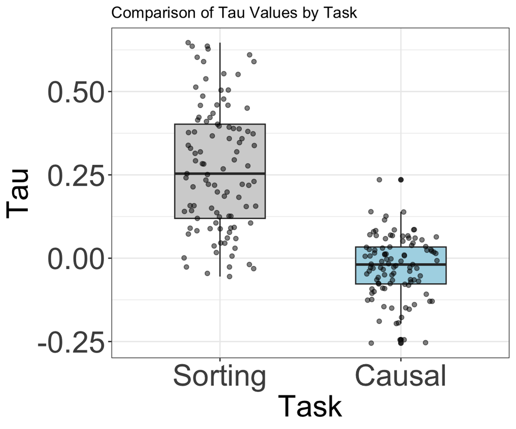

```r
combined_taus %>%
  ggplot(aes(x = task, y = tau, fill = task)) +
  geom_boxplot(width = 0.5#,
               # fill = "lightblue"
               ) +
  geom_jitter(width = 0.2, alpha = 0.5) +
  labs(title = "Comparison of Tau Values by Task",
       x = "Task",
       y = "Tau") +
  scale_fill_manual(values = c("Sorting" = "lightgray", "Causal" = "lightblue")) + #bar fill
  # scale_color_manual(values = c("Sorting Task" = "lightgray", "Causal Task" = "#4A4A4A")) +
  theme_bw() +
  theme(legend.position = "none",
        axis.text.x = element_text(size = 25),
        axis.text.y = element_text(size = 25),
        axis.title.x = element_text(size = 25),
        axis.title.y = element_text(size = 25))
```

# 11 Checkpoint: Read back in csvs

```r
#inputs
df_combined <- read_csv(paste0(snapshots_output_path, "/df_combined.csv"))
```

# 12 Order effects - Method 1

Mean Causal-causal vs Mean Freesort-freesort kendall’s correlation

```r
df_causal_first <- df_combined %>%
  filter(trial_type_order == "causation_first")

df_freesort_first <- df_combined %>%
  filter(trial_type_order == "causation_second")

# Getting causal RDMs
## causation-first group
df_causal_rdm_causation_first <- df_causal_first %>%
  mutate(item_pairs = str_c(itemA, itemB, sep = "-")) %>%
  group_by(item_pairs) %>%
  mutate(mean_causal = mean(causal_distance, na.rm = TRUE)) %>%
  ungroup() %>%
  distinct(item_pairs, .keep_all = TRUE) %>%
  select(itemA, itemB, mean_causal) %>%
  pivot_wider(names_from = itemB, values_from = mean_causal) %>%
  column_to_rownames("itemA")

df_causal_rdm_causation_first <- df_causal_rdm_causation_first[desired_order, desired_order]  #reorder rdm

## freesort-first group
df_causal_rdm_freesort_first <- df_freesort_first %>%
  mutate(item_pairs = str_c(itemA, itemB, sep = "-")) %>%
  group_by(item_pairs) %>%
  mutate(mean_causal = mean(causal_distance, na.rm = TRUE)) %>%
  ungroup() %>%
  distinct(item_pairs, .keep_all = TRUE) %>%
  select(itemA, itemB, mean_causal) %>%
  pivot_wider(names_from = itemB, values_from = mean_causal) %>%
  column_to_rownames("itemA")

df_causal_rdm_freesort_first <- df_causal_rdm_freesort_first[desired_order, desired_order]  #reorder rdm

# Getting freesort RDMs

## causation-first group
df_freesort_rdm_causation_first <- df_causal_first %>%
  mutate(item_pairs = str_c(itemA, itemB, sep = "-")) %>%
  group_by(item_pairs) %>%
  mutate(mean_euclidean = mean(freesort_distance, na.rm = TRUE)) %>%
  ungroup() %>%
  distinct(item_pairs, .keep_all = TRUE) %>%
  select(itemA, itemB, mean_euclidean) %>%
  pivot_wider(names_from = itemB, values_from = mean_euclidean) %>%
  column_to_rownames("itemA")

df_freesort_rdm_causation_first <- df_freesort_rdm_causation_first[desired_order, desired_order]  #reorder rdm

## freesort-first group
df_freesort_rdm_freesort_first <- df_freesort_first %>%
  mutate(item_pairs = str_c(itemA, itemB, sep = "-")) %>%
  group_by(item_pairs) %>%
  mutate(mean_euclidean = mean(freesort_distance, na.rm = TRUE)) %>%
  ungroup() %>%
  distinct(item_pairs, .keep_all = TRUE) %>%
  select(itemA, itemB, mean_euclidean) %>%
  pivot_wider(names_from = itemB, values_from = mean_euclidean) %>%
  column_to_rownames("itemA")

df_freesort_rdm_freesort_first <- df_freesort_rdm_freesort_first[desired_order, desired_order]  #reorder rdm


#flatten the upper tris, for correlation
flatten_rdm <- function(matrix) {
  matrix[upper.tri(matrix)]
}

m1 <- as.matrix(df_causal_rdm_causation_first)
m2 <- as.matrix(df_causal_rdm_freesort_first)

diag(m1) <- NA
diag(m2) <- NA

# Don't extract upper triangles - causal task
causation_rdm_correlation <- cor(as.vector(m1),
                                 as.vector(m2),
                                 # method = "pearson")
                                 method = "kendall",
                                 use = "complete.obs")

# Extract upper triangles - freesort task
freesort_rdm_correlation <- cor(flatten_rdm(as.matrix(df_freesort_rdm_causation_first)),
                                flatten_rdm(as.matrix(df_freesort_rdm_freesort_first)),
                                # method = "pearson")
                                method = "kendall")


print(paste0("Corr(causal rdm Causal Task first, causal rdm Sorting Task first): " , causation_rdm_correlation))
```

```
## [1] "Corr(causal rdm Causal Task first, causal rdm Sorting Task first): 0.841272736435007"
```

```r
print(paste0("Corr(freesort rdm Causal Task first, freesort rdm Sorting Task first):  " , freesort_rdm_correlation))
```

```
## [1] "Corr(freesort rdm Causal Task first, freesort rdm Sorting Task first):  0.603005956258674"
```

```r
#compute correlation difference
correlation_difference <- causation_rdm_correlation - freesort_rdm_correlation
print(paste0("correlation difference: ", correlation_difference))
```

```
## [1] "correlation difference: 0.238266780176333"
```

```r
#=========comparing with pearsons:

#Kendall
# cor(flatten_rdm(as.matrix(df_causal_rdm_causation_first)),
#                                  flatten_rdm(as.matrix(df_causal_rdm_freesort_first)),
#                                  method = "kendall")

#Causal - Pearson
cor(flatten_rdm(as.matrix(df_causal_rdm_causation_first)),
                                 flatten_rdm(as.matrix(df_causal_rdm_freesort_first)),
                                 method = "pearson")
```

```
## [1] 0.964383
```

```r
#Freesort - pearson
cor(flatten_rdm(as.matrix(df_freesort_rdm_causation_first)),
                                 flatten_rdm(as.matrix(df_freesort_rdm_freesort_first)),
                                 method = "pearson")
```

```
## [1] 0.8871252
```

# 13 Order Effects - Method 2

## 13.1 Freesort task - grab rdms

```r
#mean helper functions
mean_freesort_rdm <- function(data, subjects) {

  data %>%
    filter(subject_id %in% subjects) %>%
    group_by(itemA, itemB) %>%
    summarise(mean_distance = mean(freesort_distance),
              .groups = "drop")
}

#split into individual rdms
df_freesort_rdm_freesort_first <- df_combined %>%
  select(-causal_distance) %>%
  filter(trial_type_order == "causation_second")

df_freesort_rdm_freesort_second <- df_combined %>%
  select(-causal_distance) %>%
  filter(trial_type_order == "causation_first")

#grab unique subjects
first_subjects <- sort(unique(df_freesort_rdm_freesort_first$subject_id)) #same as for causal rdm
second_subjects <- sort(unique(df_freesort_rdm_freesort_second$subject_id))

#grab odd & even subjects
first_odd_subjects <- first_subjects[c(TRUE, FALSE)]
first_even_subjects <- first_subjects[c(FALSE, TRUE)]

second_odd_subjects <- second_subjects[c(TRUE, FALSE)]
second_even_subjects <- second_subjects[c(FALSE, TRUE)]

#build the 4 mean rdms
freesort_task_first_odd <- mean_freesort_rdm(df_freesort_rdm_freesort_first,
                                 first_odd_subjects)
freesort_task_first_even <- mean_freesort_rdm(df_freesort_rdm_freesort_first,
                                 first_even_subjects)

freesort_task_second_odd <- mean_freesort_rdm(df_freesort_rdm_freesort_second,
                                   second_odd_subjects)
freesort_task_second_even <- mean_freesort_rdm(df_freesort_rdm_freesort_second,
                                   second_even_subjects)

#view one of the rdms as example:
freesort_task_first_odd
```

```
## # A tibble: 210 × 3
##    itemA         itemB               mean_distance
##    <chr>         <chr>                       <dbl>
##  1 become hungry choose what to do           0.618
##  2 become hungry experience pain             0.368
##  3 become hungry feel scared                 0.388
##  4 become hungry get sick                    0.332
##  5 become hungry get tired                   0.305
##  6 become hungry hear something              0.567
##  7 become hungry jump up and down            0.557
##  8 become hungry kick something              0.482
##  9 become hungry reach for something         0.546
## 10 become hungry remember something          0.608
## # ℹ 200 more rows
```

```r
# freesort_task_first_even
# freesort_task_second_odd
# freesort_task_second_even
```

## 13.2 Causal task - grab rdms

```r
#mean helper function
mean_causal_rdm <- function(data, subjects) {

  data %>%
    filter(subject_id %in% subjects) %>%
    group_by(itemA, itemB) %>%
    summarise(mean_distance = mean(causal_distance),
              .groups = "drop")
}

#split into individual rdms
df_causal_rdm_freesort_first <- df_combined %>%
  select(-freesort_distance) %>%
  filter(trial_type_order == "causation_second")

df_causal_rdm_freesort_second <- df_combined %>%
  select(-freesort_distance) %>%
  filter(trial_type_order == "causation_first")

#grab unique subjects
first_subjects <- sort(unique(df_causal_rdm_freesort_first$subject_id))
second_subjects <- sort(unique(df_causal_rdm_freesort_second$subject_id))

first_odd_subjects <- first_subjects[c(TRUE, FALSE)]
first_even_subjects <- first_subjects[c(FALSE, TRUE)]

second_odd_subjects <- second_subjects[c(TRUE, FALSE)]
second_even_subjects <- second_subjects[c(FALSE, TRUE)]

#build the 4 mean rdms
causal_task_first_odd <- mean_causal_rdm(
  df_causal_rdm_freesort_first,
  first_odd_subjects)

causal_task_first_even <- mean_causal_rdm(
  df_causal_rdm_freesort_first,
  first_even_subjects)

causal_task_second_odd <- mean_causal_rdm(
  df_causal_rdm_freesort_second,
  second_odd_subjects)

causal_task_second_even <- mean_causal_rdm(
  df_causal_rdm_freesort_second,
  second_even_subjects)

#view one of the rdms as example:
causal_task_first_odd
```

```
## # A tibble: 210 × 3
##    itemA         itemB               mean_distance
##    <chr>         <chr>                       <dbl>
##  1 become hungry choose what to do           0.154
##  2 become hungry experience pain             0.259
##  3 become hungry feel scared                 0.494
##  4 become hungry get sick                    0.378
##  5 become hungry get tired                   0.298
##  6 become hungry hear something              0.640
##  7 become hungry jump up and down            0.648
##  8 become hungry kick something              0.625
##  9 become hungry reach for something         0.274
## 10 become hungry remember something          0.276
## # ℹ 200 more rows
```

```r
# causal_task_first_even
# causal_task_second_odd
# causal_task_second_even
```

## 13.3 Odd-even split correlations

### 13.3.1 Freesort task

```r
#correlation function
rdm_tau <- function(first_rdm, second_rdm) {

  merged_rdm <- first_rdm %>%
    inner_join(second_rdm,
               by = c("itemA", "itemB"),
               suffix = c("_first", "_second"))

  cor(merged_rdm$mean_distance_first,
      merged_rdm$mean_distance_second,
      method = "kendall")
}

#within-order split-half similarities
within_first_tau <- rdm_tau(freesort_task_first_odd,
                            freesort_task_first_even)

within_second_tau <- rdm_tau(freesort_task_second_odd,
                             freesort_task_second_even)

#cross-order similarities
cross_order_tau_1 <- rdm_tau(freesort_task_first_odd,
                             freesort_task_second_odd)

cross_order_tau_2 <- rdm_tau(freesort_task_first_odd,
                             freesort_task_second_even)

cross_order_tau_3 <- rdm_tau(freesort_task_first_even,
                             freesort_task_second_odd)

cross_order_tau_4 <- rdm_tau(freesort_task_first_even,
                             freesort_task_second_even)


freesort_task_order_correlations <- tibble(freesort_comparison = c(
                                            "within_first_odd_even", "within_second_odd_even",
                                            "cross_order_first_odd_second_odd",
                                            "cross_order_first_odd_second_even",
                                            "cross_order_first_even_second_odd",
                                            "cross_order_first_even_second_even"),
                                           freesort_comparison_type = c(rep("within", 2),
                                                               "cross_within",
                                                               "cross-cross",
                                                               "cross-cross",
                                                               "cross-within"),
                                           tau = c(
                                            within_first_tau, within_second_tau,
                                            cross_order_tau_1, cross_order_tau_2,
                                            cross_order_tau_3, cross_order_tau_4)) %>%
  group_by(freesort_comparison_type) %>%
  mutate(mean_comparison_type_tau = mean(tau)) %>%
  ungroup()

freesort_task_order_correlations
```

```
## # A tibble: 6 × 4
##   freesort_comparison        freesort_comparison_…¹   tau mean_comparison_type…²
##   <chr>                      <chr>                  <dbl>                  <dbl>
## 1 within_first_odd_even      within                 0.586                  0.582
## 2 within_second_odd_even     within                 0.578                  0.582
## 3 cross_order_first_odd_sec… cross_within           0.470                  0.470
## 4 cross_order_first_odd_sec… cross-cross            0.615                  0.562
## 5 cross_order_first_even_se… cross-cross            0.509                  0.562
## 6 cross_order_first_even_se… cross-within           0.597                  0.597
## # ℹ abbreviated names: ¹freesort_comparison_type, ²mean_comparison_type_tau
```

### 13.3.2 Causal Pairs task

```r
#within-order split-half similarities
within_first_tau <- rdm_tau(causal_task_first_odd,
                            causal_task_first_even)

within_second_tau <- rdm_tau(causal_task_second_odd,
                             causal_task_second_even)

#cross-order similarities
cross_order_tau_1 <- rdm_tau(causal_task_first_odd,
                             causal_task_second_odd)

cross_order_tau_2 <- rdm_tau(causal_task_first_odd,
                             causal_task_second_even)

cross_order_tau_3 <- rdm_tau(causal_task_first_even,
                             causal_task_second_odd)

cross_order_tau_4 <- rdm_tau(causal_task_first_even,
                             causal_task_second_even)


causal_task_order_correlations <- tibble(causal_comparison = c(
                                            "within_first_odd_even", "within_second_odd_even",
                                            "cross_order_first_odd_second_odd",
                                            "cross_order_first_odd_second_even",
                                            "cross_order_first_even_second_odd",
                                            "cross_order_first_even_second_even"),
                                           causal_comparison_type = c(rep("within", 2),
                                                               "cross_within",
                                                               "cross-cross",
                                                               "cross-cross",
                                                               "cross-within"),
                                           tau = c(
                                            within_first_tau, within_second_tau,
                                            cross_order_tau_1, cross_order_tau_2,
                                            cross_order_tau_3, cross_order_tau_4)) %>%
  group_by(causal_comparison_type) %>%
  mutate(mean_comparison_type_tau = mean(tau)) %>%
  ungroup()

causal_task_order_correlations
```

```
## # A tibble: 6 × 4
##   causal_comparison          causal_comparison_type   tau mean_comparison_type…¹
##   <chr>                      <chr>                  <dbl>                  <dbl>
## 1 within_first_odd_even      within                 0.773                  0.761
## 2 within_second_odd_even     within                 0.749                  0.761
## 3 cross_order_first_odd_sec… cross_within           0.783                  0.783
## 4 cross_order_first_odd_sec… cross-cross            0.780                  0.764
## 5 cross_order_first_even_se… cross-cross            0.748                  0.764
## 6 cross_order_first_even_se… cross-within           0.765                  0.765
## # ℹ abbreviated name: ¹mean_comparison_type_tau
```

## 13.4 Random split correlations

### 13.4.1 Freesort task

```r
split_subjects_in_half <- function(subjects) {

  shuffled_subjects <- sample(subjects)
  half_point <- floor(length(shuffled_subjects) / 2)

  list(first_half = shuffled_subjects[1:half_point],
       second_half = shuffled_subjects[(half_point + 1):length(shuffled_subjects)])
}

random_split_freesort_order_taus <- function(data) {

  df_freesort_first <- data %>%
    filter(trial_type_order == "causation_second")

  df_freesort_second <- data %>%
    filter(trial_type_order == "causation_first")

  freesort_first_subjects <- sort(unique(df_freesort_first$subject_id))
  freesort_second_subjects <- sort(unique(df_freesort_second$subject_id))

  freesort_first_split <- split_subjects_in_half(freesort_first_subjects)
  freesort_second_split <- split_subjects_in_half(freesort_second_subjects)

  freesort_first_half_1 <- mean_freesort_rdm(df_freesort_first,
                                             freesort_first_split$first_half)

  freesort_first_half_2 <- mean_freesort_rdm(df_freesort_first,
                                             freesort_first_split$second_half)

  freesort_second_half_1 <- mean_freesort_rdm(df_freesort_second,
                                              freesort_second_split$first_half)

  freesort_second_half_2 <- mean_freesort_rdm(df_freesort_second,
                                              freesort_second_split$second_half)

  within_first_tau <- rdm_tau(freesort_first_half_1,
                              freesort_first_half_2)

  within_second_tau <- rdm_tau(freesort_second_half_1,
                               freesort_second_half_2)

  cross_order_tau_1 <- rdm_tau(freesort_first_half_1,
                               freesort_second_half_1)

  cross_order_tau_2 <- rdm_tau(freesort_first_half_1,
                               freesort_second_half_2)

  cross_order_tau_3 <- rdm_tau(freesort_first_half_2,
                               freesort_second_half_1)

  cross_order_tau_4 <- rdm_tau(freesort_first_half_2,
                               freesort_second_half_2)

  tibble(within_first_tau = within_first_tau,
         within_second_tau = within_second_tau,
         mean_within_tau = mean(c(within_first_tau, within_second_tau)),
         mean_cross_order_tau = mean(c(cross_order_tau_1,
                                  cross_order_tau_2,
                                  cross_order_tau_3,
                                  cross_order_tau_4)),
         difference = mean_within_tau - mean_cross_order_tau)
  }

set.seed(123)

freesort_order_split_results <- bind_rows(replicate(1000,
                                                    random_split_freesort_order_taus(df_combined),
                                                    simplify = FALSE))

freesort_order_split_results_summarized <- freesort_order_split_results %>%
  summarise(mean_within_tau = mean(mean_within_tau),
            mean_cross_order_tau = mean(mean_cross_order_tau),
            mean_difference = mean(difference),
            difference_ci_low = quantile(difference, .025),
            difference_ci_high = quantile(difference, .975)#,
            # proportion_within_greater_than_cross_order = mean(difference > 0)
            )

freesort_order_split_results_summarized
```

```
## # A tibble: 1 × 5
##   mean_within_tau mean_cross_order_tau mean_difference difference_ci_low
##             <dbl>                <dbl>           <dbl>             <dbl>
## 1           0.560                0.539          0.0219           -0.0217
## # ℹ 1 more variable: difference_ci_high <dbl>
```

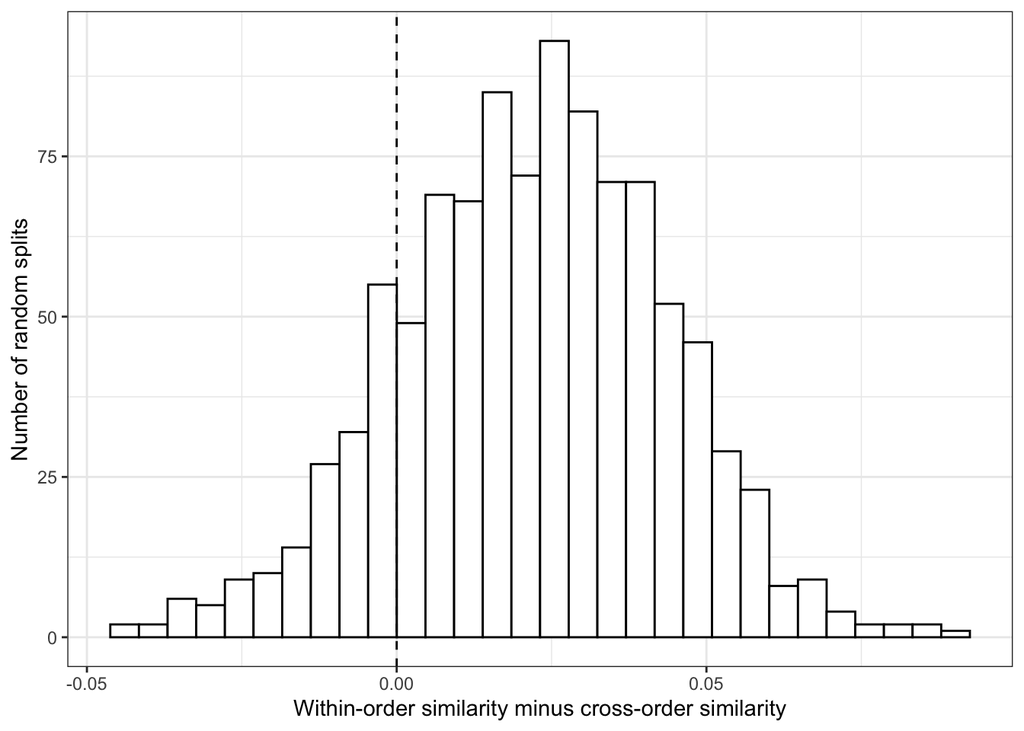

```r
ggplot(freesort_order_split_results, aes(x = difference)) +
  geom_histogram(bins = 30, color = "black", fill = "white") +
  geom_vline(xintercept = 0, linetype = "dashed") +
  theme_bw() +
  labs(
    x = "Within-order similarity minus cross-order similarity",
    y = "Number of random splits")
```

### 13.4.2 Causal task

```r
split_subjects_in_half <- function(subjects) {

  shuffled_subjects <- sample(subjects)
  half_point <- floor(length(shuffled_subjects) / 2)

  list(first_half = shuffled_subjects[1:half_point],
       second_half = shuffled_subjects[(half_point + 1):length(shuffled_subjects)])
}

random_split_causal_order_taus <- function(data) {

  df_causal_first <- data %>%
    filter(trial_type_order == "causation_second")

  df_causal_second <- data %>%
    filter(trial_type_order == "causation_first")

  causal_first_subjects <- sort(unique(df_causal_first$subject_id))
  causal_second_subjects <- sort(unique(df_causal_second$subject_id))

  causal_first_split <- split_subjects_in_half(causal_first_subjects)
  causal_second_split <- split_subjects_in_half(causal_second_subjects)

  causal_first_half_1 <- mean_causal_rdm(df_causal_first,
                                             causal_first_split$first_half)

  causal_first_half_2 <- mean_causal_rdm(df_causal_first,
                                             causal_first_split$second_half)

  causal_second_half_1 <- mean_causal_rdm(df_causal_second,
                                              causal_second_split$first_half)

  causal_second_half_2 <- mean_causal_rdm(df_causal_second,
                                              causal_second_split$second_half)

  within_first_tau <- rdm_tau(causal_first_half_1,
                              causal_first_half_2)

  within_second_tau <- rdm_tau(causal_second_half_1,
                               causal_second_half_2)

  cross_order_tau_1 <- rdm_tau(causal_first_half_1,
                               causal_second_half_1)

  cross_order_tau_2 <- rdm_tau(causal_first_half_1,
                               causal_second_half_2)

  cross_order_tau_3 <- rdm_tau(causal_first_half_2,
                               causal_second_half_1)

  cross_order_tau_4 <- rdm_tau(causal_first_half_2,
                               causal_second_half_2)

  tibble(within_first_tau = within_first_tau,
         within_second_tau = within_second_tau,
         mean_within_tau = mean(c(within_first_tau, within_second_tau)),
         mean_cross_order_tau = mean(c(cross_order_tau_1,
                                  cross_order_tau_2,
                                  cross_order_tau_3,
                                  cross_order_tau_4)),
         difference = mean_within_tau - mean_cross_order_tau)
  }

set.seed(123)

causal_order_split_results <- bind_rows(replicate(1000,
                                                    random_split_causal_order_taus(df_combined),
                                                    simplify = FALSE))

causal_order_split_results_summarized <- causal_order_split_results %>%
  summarise(mean_within_tau = mean(mean_within_tau),
            mean_cross_order_tau = mean(mean_cross_order_tau),
            mean_difference = mean(difference),
            difference_ci_low = quantile(difference, .025),
            difference_ci_high = quantile(difference, .975)#,
            # proportion_within_greater_than_cross_order = mean(difference > 0)
            )

causal_order_split_results_summarized
```

```
## # A tibble: 1 × 5
##   mean_within_tau mean_cross_order_tau mean_difference difference_ci_low
##             <dbl>                <dbl>           <dbl>             <dbl>
## 1           0.764                0.770        -0.00539           -0.0183
## # ℹ 1 more variable: difference_ci_high <dbl>
```

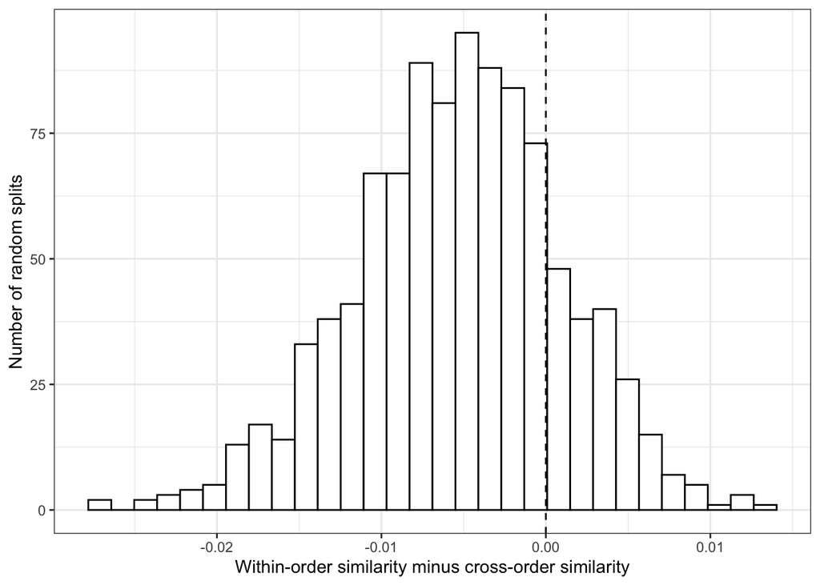

```r
ggplot(causal_order_split_results, aes(x = difference)) +
  geom_histogram(bins = 30, color = "black", fill = "white") +
  geom_vline(xintercept = 0, linetype = "dashed") +
  theme_bw() +
  labs(
    x = "Within-order similarity minus cross-order similarity",
    y = "Number of random splits")
```

## 13.5 save outputs

# 14 THE END